# **Projet : Machine Learning for Data Science**

**Binôme : Alexander Lunel & Najim Djareddir**  
**Groupe 19**  
**Enseignant : N. Veerapen**  
**Année universitaire 2024 - 2025**

Le projet a été réalisé avec GitHub pour faciliter le travail collaboratif.  
De plus, nous avons tester beaucoup de chose que nous ne pouvons pas mettre dans ce notebook pour des raisons de lisibilité et de compréhension clair du sujet traité. Néanmoins, si vous souhaitez explorer notre travail dans son intégralité, vous trouverez ci-après le lien du répertoire Git : https://github.com/Jadorlo/Projet_ml

# **`1.Introduction / Sélection des données`**

#### Identifiez au moins un jeu de données pour le projet. Décrivez vos motivations, le processus de recherche.

Réponse :

Alexander et moi sommes très intéressés par le domaine du trading appliqué aux **cryptomonnaies**, nous avons donc décider de faire un projet de machine learning sur les cryptomonnaies.

Un des premiers but de ce projet est de **réaliser une étude prédictive sur la tendance du cours du bitcoin (prédit si à n+1 le cours baissera ou augmentera)**, qui est la principale cryptomonnaie du marché, que ce soit en termes de volume échanger sur les différents échangeurs de cryptomonnaie ou en termes de prix atteint, avec récemment le dépassement des 100 000$ LE bitcoin.

L'exercice savère difficile, c'est un environnement sujet à une **volatilité extrême**, ses paramètres changent constamment. C'est un marché qui est toujours ouvert contrairement aux marché plus classiques comme à la bourse.

Plusieurs modèles devront être testés pour essayer de faire ressortir quelque chose de pertinant en termes de prédiction.

Nous avons donc rechercher un jeu de données. Étant donné que nous sommes nous même propriétaires de comptes d'exchange, sur ces derniers on a à disposition des API pour requêter les données relatives au marché. Cela concerne les cours des différentes cryptomonnaies référencées sur l'exchange, le cours actuelle, l'historique, les ouvertures, les fermetures, les plus haut, les plus bas, le volume... Il a donc parru naturelle d'aller chercher et constituer nous-même notre propre jeu de données.

Mais nous avons également cherché sur **Kaggle** un jeu de données. Nous avons rencontrés des difficultés à trouver ce type de jeu, les jeux de données sur ce type de sujet sont dur à trouvés, surtout pour en avoir un de qualité, en générale, les datasets de ce type sur Kaggle sont de mauvaise qualité, beaucoup d'incohérence, pas beaucoup de diversité de colonnes, et un historique assez faible.

#### Utilisez l’IA pour explorer des sources de données ouvertes, générer des idées de problématiques ou identifier des angles d’analyse inédits.

Réponse de ChatGPT orienté machine learning :

**Exploration de sources de données ouvertes pour Machine Learning :**

1.Données financières :

- CoinMarketCap / CoinGecko : Données sur les prix, volumes, capitalisations, historisations pour la modélisation prédictive.
- CryptoCompare : Paires de trading et données historiques pour le développement de modèles de prévision.
- Kaiko API : Données d'ordre book (niveaux de liquidité) pour entraîner des modèles sur les comportements du marché.

2.Données on-chain :

- Glassnode et IntoTheBlock : Indicateurs on-chain comme les flux vers les exchanges, activité des portefeuilles et métriques réseau.
- Etherscan API : Données transactionnelles détaillées (interactions avec les contrats intelligents, frais de gas).
- The Graph : Sources décentralisées de données, exploitables via des requêtes pour la formation de modèles analytiques.

3.Données sociales et sentimentales :

- Twitter API : Sentiment public autour des cryptomonnaies basé sur les hashtags, mentions et tendances.
- Reddit : Discussions dans des sous-forums tels que r/CryptoCurrency, pour capturer les opinions communautaires.
- Google Trends : Popularité des termes liés aux cryptomonnaies.

4.Données sur les événements et régulations :

- CryptoPanic API : Alertes sur les actualités (hacks, annonces régulatoires) pouvant influencer les marchés.
- Santiment API : Analyse combinée des signaux sociaux et des mouvements de marché.

**Idées de problématiques spécifiques au Machine Learning :**

1.Prévision des prix :

- Construire un modèle de prévision des prix basé sur des séries temporelles (ARIMA, LSTM, Transformer).
- Comparer des approches traditionnelles (régression linéaire) et avancées (réseaux neuronaux) sur des données multi-dimensionnelles (on-chain + marché).

2.Détection des anomalies et fraudes :

- Analyser les transactions inhabituelles sur les blockchains pour identifier les hacks ou les activités frauduleuses.
- Utiliser des techniques de clustering (K-Means, DBSCAN) pour détecter des modèles anormaux dans les flux de tokens.

3.Analyse sentimentale :

- Entraîner un modèle NLP pour évaluer l’impact des sentiments des réseaux sociaux (Twitter, Reddit) sur les variations des prix.
- Utiliser des embeddings comme BERT ou Word2Vec pour capturer la dynamique des mots-clés dans les discussions crypto.

4.Optimisation des stratégies de trading :

- Créer des algorithmes de reinforcement learning pour élaborer des stratégies de trading automatique.
- Utiliser des prédictions de volatilité pour ajuster le timing des transactions.

5.Analyse prédictive des événements réseau :

- Utiliser des modèles de classification pour prédire les congestions réseau basées sur les frais de gas et le volume de transactions.
- Prédire les liquidations dans les protocoles DeFi en utilisant des modèles de regression (gradient boosting).

6.Clustering des comportements utilisateurs :

- Segmenter les portefeuilles actifs en groupes basés sur leur comportement (long terme, traders actifs, baleines).
- Utiliser des algorithmes non supervisés pour comprendre les patterns d’adoption sur de nouveaux blockchains.

**Angles d’analyse inédits via Machine Learning :**

1.Analyse inter-chaînes (cross-chain) :

- Construire un graphe multi-chaînes et utiliser des modèles GNN (Graph Neural Networks) pour identifier les schémas de flux inter-chaînes.
- Étudier l’impact des exploits sur les ponts cross-chain (hacks) et prédire les vulnérabilités.

2.Impact des annonces sur le marché :

- Modéliser l’effet des annonces institutionnelles ou législatives à l’aide de modèles de classification supervisée.
- Mesurer l’impact de ces annonces en combinant NLP et séries temporelles.

3.Analyse des frais de gas :

- Utiliser des séries temporelles pour prédire l’évolution des frais de gas et suggérer des fenêtres de transaction optimales.
- Appliquer des modèles bayésiens pour comprendre les dépendances entre congestion réseau et activités sur des DApps spécifiques.

4.Optimisation écologique :

- Utiliser des modèles de prédiction pour anticiper les variations de consommation énergétique des blockchains PoW.
- Identifier des tendances dans la migration des mineurs en fonction de la rentabilité énergétique.

5.Détection des schémas de manipulation de marché :

- Entraîner des modèles pour détecter des schémas de Pump and Dump à partir de données de trading en temps réel.
- Identifier des corrélations suspectes entre les mouvements de grands portefeuilles et les fluctuations soudaines.

**Projets pratiques de Machine Learning à proposer :**

1.Modèle de prévision multi-dimensionnel :

- Données : Historique des prix, flux on-chain, tendances sociales.
- Approche : Fusion de données hétérogènes pour entraîner un modèle Transformer ou LSTM.

2.Détection de comportements atypiques sur Ethereum :

- Données : Historique des transactions, interactions avec des contrats spécifiques.
- Modèles : Clustering non supervisé pour détecter les anomalies.

3.Optimisation de trading algorithmique :

- Données : Ordres de marché et historiques.
- Approche : Utiliser le reinforcement learning pour adapter la stratégie aux conditions dynamiques.

#### Analyse critique : L’outil a-t-il proposé des idées pertinentes ou redondantes ?

Réponse :

L'outil à proposé des idées pertinantes en générale.  
Sur l'idée proposé *"Exploration des données ouvertes", le point 1.Données financière*, l'outil liste des API où on peut puiser de la données de manière libre, mais en creusant on se rend compte que les API sont gratuites que pour une certaine quantité de requêtes, en générale 500, après les prix explosent pour les utiliser, allant de 100$ à 500$.

L'idée la plus intéressante, même si elle paraît très complexe à mettre en place est celle dans *Angle d'analyse inédits, '5.Détection des schémas de manipulation de marché'*. En effet, la manipulation de marché sur les places boursières sont des secrets bien gardés, et souvent considérés comme illégaux auprès des autorités de marché. Une branche de ce type de manipulation s'appelle le **délit d'initié**, certains intervenant sur ces marchés sont informés **avant les autres** d'une grosse vente ou d'un gros achat d'actif, permettant de prendre des mesures préventives en suivant le mouvement, parier sur une baisse ou une hausse pour empocher des grosses sommes est possible.

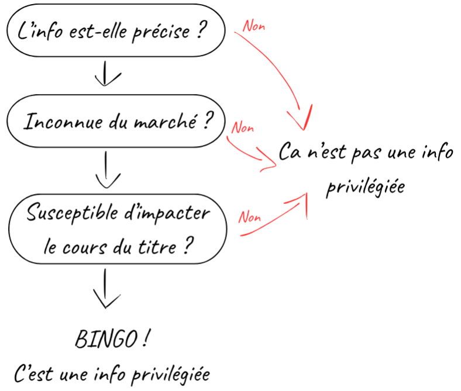

De plus, la manipulation des marchés est possible si de gros acteurs, portefeuilles, sont de la partie, par exemple on peut très bien imaginer BlackRock vendre énormément d'actifs détenus pour faire tomber les individus ayant placés des prix de vente non loin du prix actuelle, dans le seul but de faire baisser le prix de l'actif encore plus et pouvoir peut-être en racheter à un prix plus intéressant.

#### Faites le choix définitif du jeu de données. Expliquez ce choix.

Réponse :

Nous avons décidé de requêter les données via **l'API de Binance** qui est un exchange de cryptomonnaie. On va pouvoir récupérer les données avec un script d'extract. Nous avons choisi ces données et cette méthode de récupération car l'API offre plusieurs possibilités et caractéristiques :

- **Les données sont complètes** : les marchés de cryptomonnaie sont ouverts 24h/24h 7j/7j, l'API binance permet un accès à ces données, de manière **gratuite** (il suffit d'avoir un compte), elle permet une meilleure **qualité des données** que n'importe quel dataset sur kaggle ou autre.
- **Différent temps disponible** : on peut récupérer des données sur différents temps de trading. De manière générale, le trading se déroule selon des temporalités spécifiques. Par exemple : un trader peut être un trader à 5 minutes, c'est-à-dire qu'il va jouer les petits mouvements pour capitaliser dessus. Le day trading verra un investisseur ouvrir et clôturer toutes ses positions avant la clôture des marchés pour la soirée, mais en crypto les marchés sont tout le temps ouverts donc dans la pratique un trader peut quand même utiliser cette stratégie mais c'est lui qui pose ses horaires d'arrêt de trade. On peut augmenter la granularité du day training en passant à un trading par tranche de 6h, 2h, 1h... **Nous avons décidé de notre côté de rester sur un dataset par tranche de 1 jour pour la modélisation.**

Voici les données disponibles dans notre dataset :

- **date_utc** : horodatage de l'enregistrement, format AAAA-MM-JJ HH:MM:SS
- **Open_price** : prix d'ouverture à l'horodatage donné
- **High_price** : prix le plus haut atteint lors de la séance
- **Low_price** : prix le plus bas atteint lors de la séance
- **Close_price : prix de fermeture de la séance (dernier prix, variable cible)**
- **Volume** : volume échanger durant la séance en BTC
- **Quote_volume** : volume échanger durant la séance en dollars
- **Nb_trades** : nombre d'échange dans l'horodatage donné
- **Taker_buy_base_volume** : volume de BTC acheter par les preneurs
- **Taker_buy_quote_volume** : volume en $ acheté par les preneurs

# **`2.Exploration et traitement des données`**

- Identifiez et décrivez les caractéristiques des données. Effectuez les prétraitements nécessaires à ce stade.

## Importation des librairies

```python
import pandas as pd
import numpy as np
import matplotlib.pyplot as plt
from datetime import datetime

from ta.momentum import RSIIndicator
from ta.trend import EMAIndicator, MACD

from sklearn.model_selection import train_test_split
from sklearn.preprocessing import MinMaxScaler
from sklearn.metrics import mean_squared_error
from sklearn.neural_network import MLPRegressor
```

## Importation des données

```python
base = pd.read_csv(r"..\data\dataset_raw_1d_2017_08_17_2025_01_08.csv").drop(columns=["Close_time", "Ignore"])
base = base.rename(columns = {'Open_time': 'date_utc'})
base.head(5)
```

|  | date_utc | Open_price | High_price | Low_price | Close_price | Volume | Quote_volume | Nb_trades | Taker_buy_base_volume | Taker_buy_quote_volume |
| --- | --- | --- | --- | --- | --- | --- | --- | --- | --- | --- |
| 0 | 2017-08-17 | 4261.48 | 4485.39 | 4200.74 | 4285.08 | 795.150377 | 3.454770e+06 | 3427 | 616.248541 | 2.678216e+06 |
| 1 | 2017-08-18 | 4285.08 | 4371.52 | 3938.77 | 4108.37 | 1199.888264 | 5.086958e+06 | 5233 | 972.868710 | 4.129123e+06 |
| 2 | 2017-08-19 | 4108.37 | 4184.69 | 3850.00 | 4139.98 | 381.309763 | 1.549484e+06 | 2153 | 274.336042 | 1.118002e+06 |
| 3 | 2017-08-20 | 4120.98 | 4211.08 | 4032.62 | 4086.29 | 467.083022 | 1.930364e+06 | 2321 | 376.795947 | 1.557401e+06 |
| 4 | 2017-08-21 | 4069.13 | 4119.62 | 3911.79 | 4016.00 | 691.743060 | 2.797232e+06 | 3972 | 557.356107 | 2.255663e+06 |

## Exploration des données

L'exploration des données permet de mieux appréhender le sujet que l'on va traiter. Cette analyse est réalisée avec des graphiques matplotlib, la construction de variables nouvelles pour essayer de capter certains mouvements comme les variations en pourcentage par jour et mois, consigné dans des tableux.

```
Analyse des variables numériques :
```

|  | Open_price | High_price | Low_price | Close_price | Volume | Quote_volume | Nb_trades | Taker_buy_base_volume | Taker_buy_quote_volume |
| --- | --- | --- | --- | --- | --- | --- | --- | --- | --- |
| count | 2707.00 | 2707.00 | 2707.00 | 2707.00 | 2707.00 | 2.707000e+03 | 2707.00 | 2707.00 | 2.707000e+03 |
| mean | 27326.44 | 27986.85 | 26621.23 | 27358.45 | 67874.66 | 1.721364e+09 | 1626334.33 | 33744.71 | 8.525656e+08 |
| std | 22485.11 | 22975.58 | 21981.04 | 22513.77 | 80004.17 | 2.000186e+09 | 2062647.89 | 39810.32 | 9.945137e+08 |
| min | 3188.01 | 3276.50 | 2817.00 | 3189.02 | 228.11 | 9.778657e+05 | 2153.00 | 56.19 | 2.413638e+05 |
| 25% | 8540.14 | 8789.50 | 8233.50 | 8550.93 | 27898.16 | 3.302638e+08 | 348634.00 | 14021.27 | 1.677441e+08 |
| 50% | 20236.71 | 20792.06 | 19770.51 | 20241.05 | 43560.73 | 9.978679e+08 | 938705.00 | 21666.54 | 4.904852e+08 |
| 75% | 42212.12 | 43105.50 | 41347.17 | 42234.94 | 70835.13 | 2.435900e+09 | 1828812.00 | 35320.69 | 1.206984e+09 |
| max | 106133.74 | 108353.00 | 105321.49 | 106133.74 | 760705.36 | 1.746531e+10 | 15223589.00 | 374775.57 | 8.783916e+09 |

```
Analyse des variables temporelles :
```

```
count                   2707
mean     2021-05-01 00:00:00
min      2017-08-17 00:00:00
25%      2019-06-24 12:00:00
50%      2021-05-01 00:00:00
75%      2023-03-08 12:00:00
max      2025-01-13 00:00:00
Name: date, dtype: object
```

```
Intervalle de temps des données : 7 années, 5 mois, et 1 jours

Analyse graphique :
Visualisation de la tendance du Bitcoin :
```

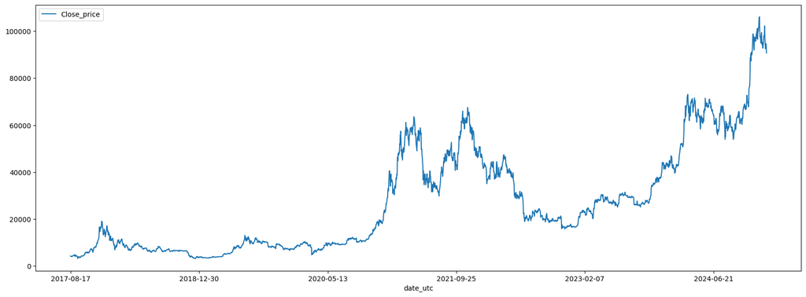

[output not shown]

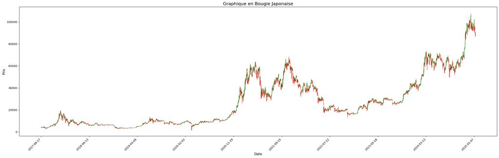

```
Évolution par mois :
```

| date_utc | evolution_prct |
| --- | --- |
| 2017-08 | 0.730078 |
| 2017-09 | -0.033643 |
| 2017-10 | 1.331101 |
| 2017-11 | 1.512356 |
| 2017-12 | 1.400577 |
| ... | ... |
| 2024-09 | 0.261611 |
| 2024-10 | 0.357071 |
| 2024-11 | 1.106979 |
| 2024-12 | -0.070809 |
| 2025-01 | -0.203156 |

90 rows × 1 columns

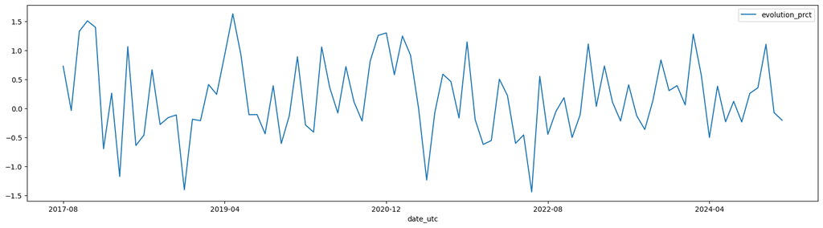

```python
def exploration_donnees(df : pd.DataFrame):

    print("Analyse des variables numériques :")
    display(df.describe().round(2))

    print("Analyse des variables temporelles :")
    df1 = df.copy()
    df1["date"] = pd.to_datetime(df1["date_utc"], format="%Y-%m-%d")
    display(df1["date"].describe())

    # Calcul de l'intervalle de temps
    intervalle = max(df1['date']) - min(df1['date'])

    # Conversion en années, mois et jours
    annees = intervalle.days // 365
    mois = (intervalle.days % 365) // 30
    jours = (intervalle.days % 365) % 30

    print(f"Intervalle de temps des données : {annees} années, {mois} mois, et {jours} jours")

    print("\nAnalyse graphique :")
    print("Visualisation de la tendance du Bitcoin :")
    df1.plot(x="date_utc", y = ["Close_price"], kind = 'line', figsize=(20,7))
    plt.show()

    print("\nAnalyse avec Bougie Japonaise journalières :")
    print("Les bougies japonaises permettent de voir")

    # Tri des données par date (important pour l'ordre chronologique)
    df1 = df1.sort_values(by="date_utc")
    df1["date_utc"] = df1["date_utc"].str[0:10]

    # Taille de la figure
    plt.figure(figsize=(25, 8))

    # Largeurs des corps des bougies et des mèches
    width = 0.65  # Largeur des corps des bougies
    width2 = 0.35  # Largeur des mèches (High et Low)

    # Couleurs pour les bougies
    col1 = 'green'  # Couleur pour les hausses
    col2 = 'red'    # Couleur pour les baisses

    # Parcourir chaque ligne pour dessiner les bougies dans l'ordre des dates
    for index, row in df1.iterrows():
        color = col1 if row["Close_price"] >= row["Open_price"] else col2

        # Tracer le corps de la bougie
        plt.bar(row["date_utc"], row["Close_price"] - row["Open_price"], width,
                bottom=min(row["Close_price"], row["Open_price"]), color=color, edgecolor=color)

        # Tracer les mèches (High et Low)
        plt.vlines(row["date_utc"], row["Low_price"], row["High_price"], color=color, linewidth=width2)

    # Ajouter un titre et des labels
    plt.title("Graphique en Bougie Japonaise", fontsize=16)
    plt.xlabel("Date", fontsize=12)
    plt.ylabel("Prix", fontsize=12)

    # Rotation des ticks sur l'axe des X pour une meilleure lisibilité
    plt.xticks(rotation=45, ha='right')

    # Ajustement de l'affichage des ticks sur l'axe des X
    plt.gca().xaxis.set_major_locator(plt.MaxNLocator(10))

    # Afficher le graphique
    plt.tight_layout()
    plt.show()

    print("\nÉvolution par mois :")
    df2 = df.copy()
    df2["date_utc"] = df2["date_utc"].str[0:7]
    df2["evolution_prct"] = df1["Close_price"].pct_change()*100
    df2 = df2.groupby(by = ["date_utc"])["evolution_prct"].mean()
    df2 = pd.DataFrame(df2)
    display(df2)
    df2.plot(kind='line', figsize=(20,5))

exploration_donnees(base)
```

## Prétraitements des données

```python
def traitement_donnees_day(df : pd.DataFrame):
    df1 = pd.DataFrame()
    df1 = df.copy()
    df1["date_utc"] = df1["date_utc"].astype(str).str[:10]

    df_jour_mois = []

    for i in df1["date_utc"]:
        date_string = i
        date_object = datetime.strptime(date_string, "%Y-%m-%d")
        jour_semaine = date_object.weekday()
        jour_nom = date_object.strftime("%A")
        mois_num = date_object.month
        # print(f"La date {date_string} correspond à : {jour_nom} (jour {jour_semaine})")

        df_jour_mois.append({
            "date_utc" : date_string,
            "lundi": 1 if jour_semaine == 0 else 0,
            "mardi" : 1 if jour_semaine == 1 else 0 ,
            "mercredi" : 1 if jour_semaine == 2 else 0,
            "jeudi" : 1 if jour_semaine == 3 else 0,
            "vendredi" : 1 if jour_semaine == 4 else 0,
            "samedi" : 1 if jour_semaine == 5 else 0,
            "dimanche" : 1 if jour_semaine == 6 else 0,
            "janvier": 1 if mois_num == 1 else 0,
            "fevrier": 1 if mois_num == 2 else 0,
            "mars": 1 if mois_num == 3 else 0,
            "avril": 1 if mois_num == 4 else 0,
            "mai": 1 if mois_num == 5 else 0,
            "juin": 1 if mois_num == 6 else 0,
            "juillet": 1 if mois_num == 7 else 0,
            "aout": 1 if mois_num == 8 else 0,
            "septembre": 1 if mois_num == 9 else 0,
            "octobre": 1 if mois_num == 10 else 0,
            "novembre": 1 if mois_num == 11 else 0,
            "decembre": 1 if mois_num == 12 else 0
        })

    df_jour_mois = pd.DataFrame(df_jour_mois)
    df1["evolution_prct"] = df1["Close_price"].pct_change()*100
    df_resultat = pd.merge(df1, df_jour_mois, on=["date_utc"])

    return df_resultat
```

```python
df_traite_day = traitement_donnees_day(base)
df_traite_day.head(5)
```

|  | date_utc | Open_price | High_price | Low_price | Close_price | Volume | Quote_volume | Nb_trades | Taker_buy_base_volume | Taker_buy_quote_volume | ... | mars | avril | mai | juin | juillet | aout | septembre | octobre | novembre | decembre |
| --- | --- | --- | --- | --- | --- | --- | --- | --- | --- | --- | --- | --- | --- | --- | --- | --- | --- | --- | --- | --- | --- |
| 0 | 2017-08-17 | 4261.48 | 4485.39 | 4200.74 | 4285.08 | 795.150377 | 3.454770e+06 | 3427 | 616.248541 | 2.678216e+06 | ... | 0 | 0 | 0 | 0 | 0 | 1 | 0 | 0 | 0 | 0 |
| 1 | 2017-08-18 | 4285.08 | 4371.52 | 3938.77 | 4108.37 | 1199.888264 | 5.086958e+06 | 5233 | 972.868710 | 4.129123e+06 | ... | 0 | 0 | 0 | 0 | 0 | 1 | 0 | 0 | 0 | 0 |
| 2 | 2017-08-19 | 4108.37 | 4184.69 | 3850.00 | 4139.98 | 381.309763 | 1.549484e+06 | 2153 | 274.336042 | 1.118002e+06 | ... | 0 | 0 | 0 | 0 | 0 | 1 | 0 | 0 | 0 | 0 |
| 3 | 2017-08-20 | 4120.98 | 4211.08 | 4032.62 | 4086.29 | 467.083022 | 1.930364e+06 | 2321 | 376.795947 | 1.557401e+06 | ... | 0 | 0 | 0 | 0 | 0 | 1 | 0 | 0 | 0 | 0 |
| 4 | 2017-08-21 | 4069.13 | 4119.62 | 3911.79 | 4016.00 | 691.743060 | 2.797232e+06 | 3972 | 557.356107 | 2.255663e+06 | ... | 0 | 0 | 0 | 0 | 0 | 1 | 0 | 0 | 0 | 0 |

5 rows × 30 columns

### Ajout des indicateurs

Les indicateurs en trading sont des éléments important pour bien comprendre la tendance actuelle et futur du marché. Ils sont utilisés par la pluspart des traders sur n'importe quelle fenêtre de temps, que ce soit du 5 minutes, 1 heure, 6 heures, jours ou mois... Ils peuvent permettre de détecter si le mouvement actuel du marché est prometteur ou pas, si la tendance s'apprête à changer ou non, si on est à un point de retournement du marché etc...

Nous avons choisis plusieurs indicateurs qui nous semble pertinent :

1. Relative Strength Index (RSI)
- Le RSI mesure la force des mouvements de prix en comparant les gains récents aux pertes récentes.  
  $ Formule : $

$$ RSI = 100 - \frac{100}{1 + RS} $$ $$ où : $$ $$ RS = \frac{\text{Moyenne des gains sur } n \text{ périodes}}{\text{Moyenne des pertes sur } n \text{ périodes}} $$

2. Exponential Moving Average (EMA)
- L’EMA donne plus de poids aux prix récents par rapport à une moyenne mobile simple (SMA).
  $ Formule : $ $$ EMA_t = \alpha \cdot P_t + (1 - \alpha) \cdot EMA_{t-1} $$ $$ où : $$ $$ \alpha = \frac{2}{n + 1} $$
3. Moving Average Convergence Divergence (MACD)
- Calculé comme la différence entre une EMA courte et une EMA longue.
- Une ligne de signal (EMA du MACD) aide à identifier les croisements pour générer des signaux d'achat ou de vente.  
  $ Formule : $

$$ MACD = EMA_{\text{rapide}} - EMA_{\text{lente}} $$

$$ \text{Signal} = EMA_{\text{signal}}(MACD) $$

```python
def ajouter_indicateurs(df: pd.DataFrame, close_col: str, rsi_period: int, ema_period: int,
                        macd_short: int, macd_long: int, macd_signal: int) -> pd.DataFrame:
    """
    Ajoute RSI, EMA, MACD au DataFrame en utilisant la bibliothèque ta.
    :param df: DataFrame contenant les données.
    :param close_col: Nom de la colonne des prix de clôture.
    :param rsi_period: Période pour le RSI.
    :param ema_period: Période pour l'EMA.
    :param macd_short: Période pour l'EMA courte du MACD.
    :param macd_long: Période pour l'EMA longue du MACD.
    :param macd_signal: Période pour la ligne de signal du MACD.
    :return: DataFrame avec les indicateurs ajoutés.
    """
    # Ajouter le RSI
    rsi = RSIIndicator(close=df[close_col], window=rsi_period)
    df['RSI'] = rsi.rsi()

    # Ajouter l'EMA
    ema = EMAIndicator(close=df[close_col], window=ema_period)
    df[f'EMA_{ema_period}'] = ema.ema_indicator()

    # Ajouter le MACD
    macd = MACD(close=df[close_col], window_slow=macd_long, window_fast=macd_short, window_sign=macd_signal)
    df['MACD'] = macd.macd()
    df['MACD_Signal'] = macd.macd_signal()

    return df
```

```python
df_traite_day = ajouter_indicateurs(df= df_traite_day, close_col= "Close_price", rsi_period=14,
                                    ema_period=14, macd_short=12, macd_long=26, macd_signal=9)
display(df_traite_day)
```

|  | date_utc | Open_price | High_price | Low_price | Close_price | Volume | Quote_volume | Nb_trades | Taker_buy_base_volume | Taker_buy_quote_volume | ... | juillet | aout | septembre | octobre | novembre | decembre | RSI | EMA_14 | MACD | MACD_Signal |
| --- | --- | --- | --- | --- | --- | --- | --- | --- | --- | --- | --- | --- | --- | --- | --- | --- | --- | --- | --- | --- | --- |
| 0 | 2017-08-17 | 4261.48 | 4485.39 | 4200.74 | 4285.08 | 795.150377 | 3.454770e+06 | 3427 | 616.248541 | 2.678216e+06 | ... | 0 | 1 | 0 | 0 | 0 | 0 | NaN | NaN | NaN | NaN |
| 1 | 2017-08-18 | 4285.08 | 4371.52 | 3938.77 | 4108.37 | 1199.888264 | 5.086958e+06 | 5233 | 972.868710 | 4.129123e+06 | ... | 0 | 1 | 0 | 0 | 0 | 0 | NaN | NaN | NaN | NaN |
| 2 | 2017-08-19 | 4108.37 | 4184.69 | 3850.00 | 4139.98 | 381.309763 | 1.549484e+06 | 2153 | 274.336042 | 1.118002e+06 | ... | 0 | 1 | 0 | 0 | 0 | 0 | NaN | NaN | NaN | NaN |
| 3 | 2017-08-20 | 4120.98 | 4211.08 | 4032.62 | 4086.29 | 467.083022 | 1.930364e+06 | 2321 | 376.795947 | 1.557401e+06 | ... | 0 | 1 | 0 | 0 | 0 | 0 | NaN | NaN | NaN | NaN |
| 4 | 2017-08-21 | 4069.13 | 4119.62 | 3911.79 | 4016.00 | 691.743060 | 2.797232e+06 | 3972 | 557.356107 | 2.255663e+06 | ... | 0 | 1 | 0 | 0 | 0 | 0 | NaN | NaN | NaN | NaN |
| ... | ... | ... | ... | ... | ... | ... | ... | ... | ... | ... | ... | ... | ... | ... | ... | ... | ... | ... | ... | ... | ... |
| 2702 | 2025-01-09 | 95060.61 | 95382.32 | 91203.67 | 92552.49 | 34544.836850 | 3.217670e+09 | 6027161 | 15323.626630 | 1.427812e+09 | ... | 0 | 0 | 0 | 0 | 0 | 0 | 41.852140 | 96512.595309 | -217.642984 | 52.541583 |
| 2703 | 2025-01-10 | 92552.49 | 95836.00 | 92206.02 | 94726.11 | 31482.864240 | 2.962085e+09 | 5531444 | 15617.438230 | 1.469712e+09 | ... | 0 | 0 | 0 | 0 | 0 | 0 | 46.524475 | 96274.397268 | -336.797900 | -25.326313 |
| 2704 | 2025-01-11 | 94726.10 | 95050.94 | 93831.73 | 94599.99 | 7047.904300 | 6.656860e+08 | 1496191 | 3412.376710 | 3.223470e+08 | ... | 0 | 0 | 0 | 0 | 0 | 0 | 46.292045 | 96051.142965 | -436.375594 | -107.536170 |
| 2705 | 2025-01-12 | 94599.99 | 95450.10 | 93711.19 | 94545.06 | 8606.866220 | 8.132788e+08 | 1658863 | 4028.330310 | 3.806918e+08 | ... | 0 | 0 | 0 | 0 | 0 | 0 | 46.183824 | 95850.331903 | -513.801245 | -188.789185 |
| 2706 | 2025-01-13 | 94545.07 | 95940.00 | 90300.00 | 90752.00 | 23010.208890 | 2.124497e+09 | 3149930 | 10020.672480 | 9.266445e+08 | ... | 0 | 0 | 0 | 0 | 0 | 0 | 39.343969 | 95170.554316 | -871.187367 | -325.268821 |

2707 rows × 34 columns

## Critique du travail par l'IA

- Demandez à l’IA de critiquer constructivement votre approche.  
  Réponse :

**Partie 1 : Exploration des données**

**Points forts :**

1.Analyse descriptive complète :

- Vous fournissez une description statistique des variables numériques avec df.describe().
- L’analyse temporelle (**date.describe()** et intervalle de temps) est pertinente pour des données de séries temporelles.

2.Graphiques clairs et pertinents :

- L’utilisation d’un graphique linéaire pour visualiser la tendance du Bitcoin est un bon choix pour explorer rapidement l’évolution des prix dans le temps.
- Le graphique en bougies japonaises est bien construit et utile pour détecter les patterns journaliers (hausses/baisse).

3.Inclusion de la variabilité temporelle (par mois) :

- L’évolution mensuelle avec **pct_change()** est intéressante pour identifier les périodes avec de grandes variations.

**Limites et suggestions :**

1.Clarté et structure du code :

- Le code est dense, ce qui pourrait rendre sa maintenance difficile. Il serait utile d’externaliser certaines parties en fonctions modulaires (par ex., création du graphique en bougies japonaises).

2.Interprétation des données :

- Les résultats des statistiques descriptives et des graphiques ne sont pas explicitement interprétés (par exemple, comment les variations mensuelles influencent-elles les décisions ?).

3.Gestion des données manquantes et outliers :

- Aucune analyse des valeurs manquantes ou des valeurs aberrantes (outliers) n’est effectuée, ce qui est crucial dans l’exploration des données pour des séries temporelles.

4.Bougies japonaises :

- Le graphique est intéressant mais pourrait être enrichi. Par exemple :
  - Ajouter des lignes de tendance ou des moyennes mobiles (e.g., MA, EMA).
  - Améliorer la lisibilité en utilisant des marqueurs pour les dates-clés.

5.Ajout d'annotations sur les tendances :

- Vous pourriez identifier et annoter les périodes clés, comme des pics ou des crashes significatifs, pour enrichir l’exploration.

**Partie 2 : Prétraitement des données**

**Points forts :**

1.Encodage temporel enrichi :

2.Calcul de la variation en pourcentage :

- L’ajout de la colonne evolution_prct est utile pour comprendre les changements relatifs dans le prix.

3.Structure du code :

- Votre boucle pour extraire les features temporelles est fonctionnelle et montre une bonne compréhension des opérations de manipulation de données.

**Limites et suggestions :**

1.Performance :

- La boucle pour créer les colonnes temporelles pourrait être optimisée avec des fonctionnalités vectorisées de pandas. Par exemple :
- Utilisez pd.to_datetime() directement pour extraire les jours, mois, etc., au lieu de boucler sur chaque ligne avec datetime.strptime.  
  *Exemple vectorisé :*  
  *df['lundi'] = (df['date_utc'].dt.weekday == 0).astype(int)*  
  *df['janvier'] = (df['date_utc'].dt.month == 1).astype(int)*  
  *Cela améliorerait considérablement les performances pour de grandes bases de données.*

2.Généralisation des plages horaires :

3.Validation des données dérivées :

- Il manque une vérification des colonnes créées (par exemple, vérifier que chaque observation a exactement un jour de la semaine activé).

4.Gestion des données manquantes :

- Vous ne traitez pas explicitement les données manquantes. Si des valeurs manquantes existent dans Close_price ou d'autres colonnes, cela pourrait poser problème pour le calcul de pct_change.

5.Standardisation :

- Les colonnes créées (e.g., jours, mois) sont bien encodées en variables binaires, mais vous pourriez envisager une standardisation ou normalisation pour les variables numériques comme Open_price, Close_price, etc., afin de les rendre adaptées à des modèles d’apprentissage automatique.

**Suggestions générales d’amélioration**

1.Modularisation :

- Séparez les fonctions principales en plusieurs petites fonctions. Par exemple :
  - Une fonction dédiée à l’encodage temporel.
  - Une fonction pour le calcul de la variation en pourcentage.
  - Une fonction pour vérifier les valeurs manquantes ou aberrantes.

2.Ajout de tests pour les fonctions :

- Testez chaque fonction sur un petit sous-ensemble de données pour valider les résultats. Par exemple :
  - Valider que evolution_prct est bien calculée.
  - Vérifier que les colonnes binaires (jours et mois) contiennent des valeurs cohérentes.

3.Intégration de visualisations interactives :

- Vous pourriez envisager d’utiliser des bibliothèques comme Plotly ou Bokeh pour rendre vos graphiques interactifs. Cela améliorerait la présentation des analyses.

4.Détection des outliers :

- Implémentez une méthode pour détecter et analyser les outliers, comme l’IQR ou des visualisations (e.g., boxplots).

5.Documentation :

- Ajoutez des docstrings à vos fonctions pour expliquer clairement leurs objectifs, entrées et sorties.

**Conclusion :**  
Votre travail montre une très bonne maîtrise des fondamentaux de l'exploration et du prétraitement des données, avec une orientation pratique et pertinente. Cependant, il pourrait être davantage optimisé pour la performance et enrichi avec des analyses complémentaires (outliers, valeurs manquantes, tendances clés). En intégrant des techniques modernes comme les visualisations interactives et des outils de vérification, vous pourriez produire une analyse encore plus robuste et professionnelle.

- Proposez une analyse du résultat et, le cas échéant, modifiez votre travail en fonction.  
  Réponse :

ChatGPT soulève des points intéressants :

- **Les valeurs manquantes et outliers** : il remarque que l'on a pas fait une étape importante de l'exploration de données qui est la recherche et le traitement des valeurs manquantes et aberrantes. Mais avec notre sujet et surtout la manière dont on récolte les données, nous ne sommes pas affecté par le problème des valeurs manquantes. Pour les valeurs aberrantes, il y en aurait sûrement, mais nous préférons les conserver car ce seront probablement des valeurs très élevées mais on considère que le bitcoin est une cryptomonnaie très jeune, et surtout qui n'a pas atteint son plein potentiel, supprimer ou remplacer ces valeurs aberrantes préparerai mal le modèle à affronter l'avenir évolutif du bitcoin.

Mais il se trompe également, surtout quand il propose de standardiser nos données à cette étape du projet alors que cela pourrait prduire un data leakage en appliquant cette méthode avant séparation des données en train et test.

# **`3.Modélisation et évaluation`**

## Choix et construction des modèles/pipelines

- Choisissez et construisez des modèles ou pipelines adaptés au problème.

### Utilisation de sklearn

Dans un premier temps nous avons tenter une approche avec **scikit-learn** pour essayer de répondre à notre problématique de prédiction du cours du bitcoin à la hausse comme à la baisse. Nous avons décidé de tester trois modèles différents.

- Le **RandomForestRegressor**
- Le **GradientBoostingRegressor**
- Le **Multi-Layer Perceptron (MLPRegressor)**

*Nous n'avons pas mis le code du RandomForestRegressor et du GradientBoostingRegressor pour ne pas surcharger le notebook, mais nous avons mis les résultats produits par ces deux modèles sur le graphique des résultats du MLPRegressor que l'on retrouvera plus bas.*

Le RandomForestRegressor et le GradientBoostingRegressor sont les moins bons des trois lors de la phase de prédiction sur l'ensemble de test. Il arrivent à capter les petits premiers mouvements du Bitcoin mais pas le reste, malgré que la cryptomonnaie poursuit une tendance haussière. Le réseau de neurone regressor est peu mieux que les deux autres, il arrive à capter partiellement les mouvements. C'est-à-dire qu'il capte les grandes tendances dans leur généralité, mais il est très ératique. Plus que nous sommes dans une position de trading à 1 jour de temps, capter la tendance du marché est primordiale pour ne pas se tromper dans le placement de ses positions, hors le MLPRegressor fluctue beaucoup par rapport aux valeurs réelles.

Nous pouvons le voir avec le graphique un peu plus loin.

#### Préparation des données à la modélisation

```python
df = pd.read_csv('..\data\dataset_v2_1d_2017_08_17_2025_01_08.csv').dropna()

# Colonnes utilisées comme entrées (features)
feature_columns = [
    'Open_price', 'High_price', 'Low_price', 'Close_price',
       'Volume', 'Quote_volume', 'Nb_trades', 'Taker_buy_base_volume',
       'Taker_buy_quote_volume', 'evolution_prct', 'lundi', 'mardi',
       'mercredi', 'jeudi', 'vendredi', 'samedi', 'dimanche', 'janvier',
       'fevrier', 'mars', 'avril', 'mai', 'juin', 'juillet', 'aout',
       'septembre', 'octobre', 'novembre', 'decembre', 'RSI', 'EMA_14', 'MACD',
       'MACD_Signal'
]

# Normaliser les données
scaler_features = MinMaxScaler()
scaler_target = MinMaxScaler()

X = scaler_features.fit_transform(df[feature_columns])
y = scaler_target.fit_transform(df[['Close_price']])

# Créer des séquences
def create_sequences(X, y, sequence_length):
    sequences = []
    targets = []
    for i in range(len(X) - sequence_length):
        seq = X[i:i + sequence_length].flatten()  # Aplatir les séquences
        target = y[i + sequence_length]
        sequences.append(seq)
        targets.append(target)
    return np.array(sequences), np.array(targets)

sequence_length = 28
X_seq, y_seq = create_sequences(X, y, sequence_length)

# Division des données en ensembles d'entraînement et de test
X_train, X_test, y_train, y_test = train_test_split(
    X_seq, y_seq, test_size=0.2, shuffle=False
)
```

#### Multi-Layer Input Regressor (MLPRegressor)

```python
mlp = MLPRegressor(
    hidden_layer_sizes=(64, 32, 32),  # Deux couches cachées avec 100 et 50 neurones
    activation='relu',            # Fonction d'activation ReLU
    solver='adam',                # Optimiseur Adam
    max_iter=3000,                 # Nombre maximal d'itérations
    random_state=42,
    batch_size= 30,
    learning_rate="constant",
    learning_rate_init=0.001
)

# Entraîner le modèle
mlp.fit(X_train, y_train.ravel())

# Prédictions et évaluation
y_pred_mlp = mlp.predict(X_test)
mse_mlp = mean_squared_error(y_test, y_pred_mlp)
print(f"MLP MSE: {mse_mlp:.4f}")
```

```
MLP MSE: 0.0061
```

#### Résultats des modèles RFR / MLPR / GBR

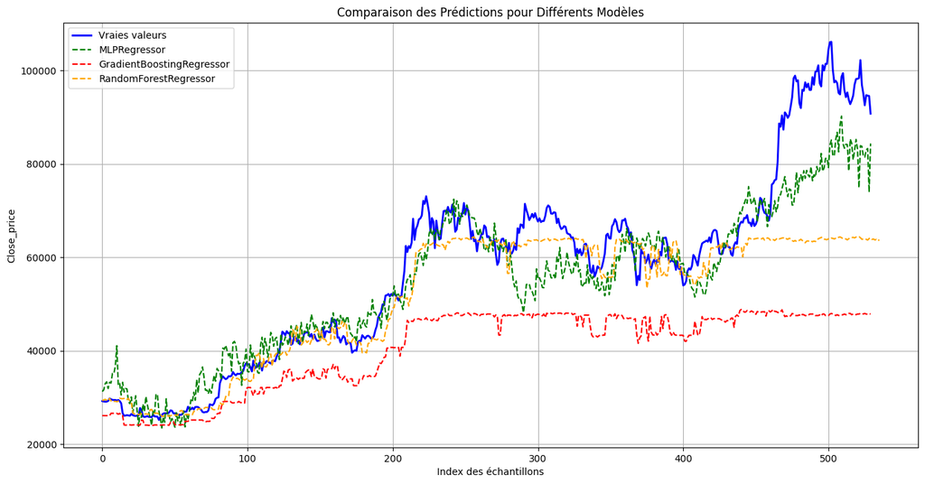

Le MLP est le seul qui arrive suivre la tendance générale du cours du Bitcoin sur toute la durée, mais on remarque que l'échelle n'est pas la même entre les valeurs réelles et les prédictions. De plus, même suit il suit la tendance générale, il est très mauvais sur le fait de prédire une hausse ou une baisse sur le jour suivant. Il va parfois en sens inverse du sens réel que prend le marché.

Pourtant ces prédictions ont été réalisées avec les variables encodées et surtout l'ajout des indicateurs, mais les résultats ne sont pas au rendez-vous. Nous nous sommes donc tourné vers un modèle pouvant essayer de répondre à notre problématique, et nous avons utilisé un LSTM avec Tensorflow.

# Modélisation avec TENSORFLOW - LSTM

Dans cette partie sur tensorflow, nous allons essayer d'améliorer les prédictions des modèles scikit learn en utilisant le modèle Long Short Term Memory ($LSTM$).

Le $LSTM$ est une variante des réseaux de neuronnes récurrent ($RNN$), c'est à dire que les neurones utilisent leur sortie comme un nouvel input. Ce type de modèle est généralement exposé à l'explosion ou la disparition du gradient à cause de leur aspect récursif.

Cependant, le $LSTM$ permet de régler ce problème en instaurant une cellule d'état. Cette cellule comporte 3 portes : porte d'oublie (% de la mémoire long terme oubliée), la porte d'entrée (création d'une mémoire long terme) et porte de sortie (création de mémoire court terme). A chaque observation, le neurone met à jour l'état de la cellule afin de récupérer l'effet long terme (tendance par exemple) et l'effet court terme (de volatilité dans notre cas).

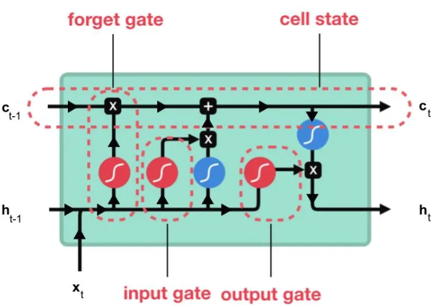

Le $LSTM$ est donc particulièrement utilisé pour effectuer des prédictions de séries temporelles et c'est ce pourquoi nous allons l'utiliser pour tenter d'améliorer les performances de nos modèles par rapport à la problématique. Pour rappel, nous devons prédire si le prix de clôture au terme du jour $N_{+1}$ va augmenter ou diminuer par rapport au jour $N$.

Pour ce faire, nous allons d'abord prédire le prix du lendemain grâce au $LSTM$, puis nous crérons des variables cibles pour mesurer la précision du modèle. Les variables évaluent si le cours a monté sur les données réelles et sur les prédictions. Nous pourrons comparer ces variables avec des métriques de classification.

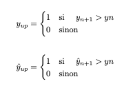

Nous allons d'abord utiliser seulement l'évolution de la variable Close_price, le prix de fermeture de chaque bougies. Nous utiliserons ensuite les autres variables permettant de créer les datasets v2 pour tenter d'améliorer le modèle.

## Présentation du modèle

Le réseau de neuronnes LSTM est composé de plusieurs couches. Une première couche d'input pour spécifier la forme de notre jeu de données en entrée. En effet, ce réseau de neuronnes demande une mise en forme particulière : Le jeu d'entrée est de dimension trois, nous y reviendrons. Pour cette raison nous devons en préciser 2, à savoir la taille de la fenêtre (window_size) et le nombre de variable (n_features), la troisième étant le nombre d'observations.

Nous enchaînons avec une couche de 256 neuronnes LSTM effectuant le traitement que nous avons évoqué précédemment. Une couche Dense de 64 neuronnes est aussi ajouté afin d'utiliser l'apprentissage d'un réseau de neuronnes classique. Les couches de Dropout permettent d'oublier un pourcentage des neuronnes de la couche précédente dans le but d'éviter l'overfitting. Nous supprimons donc 50% des neuronnes apres LSTM et 20% apres la couche dense.

L'architecture de ce modèle est inspiré de celle du papier de M. Patrick Jaquart: https://www.sciencedirect.com/science/article/pii/S2405918821000027

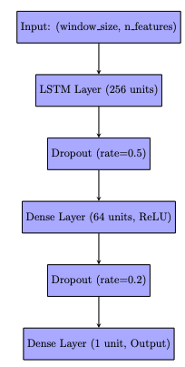

### Critique par l'IA

Questions :

D'abord décris, le modèle et ses particularités. présente le ensuite sous forme de graphe Latex. Pense tu que le modèle sera performant, si oui pourquoi, si non pourquoi. Si le modèle présenté ci dessus te semble peu efficace pour notre problématique, propose en un autre.

Réponse de l'IA :

Le modèle présenté est un réseau neuronal récurrent basé sur une architecture LSTM (Long Short-Term Memory), combinée avec des couches entièrement connectées (Dense). Voici ses composants et particularités :

Entrée (Input Layer):

- Dimension des entrées : (window_size, n_features).
- Reçoit des séquences temporelles contenant window_size pas de temps et n_features caractéristiques pour chaque pas de temps.

LSTM Layer:

- 256 unités dans la couche LSTM.
- Les LSTM sont efficaces pour capturer les dépendances temporelles et les patterns dans les données séquentielles comme les séries temporelles.

Dropout Layers:

- Dropout(0.5) après la couche LSTM.
- Dropout(0.2) après la première couche Dense.
- Les couches de dropout servent à prévenir le surapprentissage en désactivant aléatoirement une proportion donnée de neurones pendant l'entraînement.

Dense Layers:

- Une couche Dense avec 64 unités et une activation ReLU.
- Une couche Dense finale avec une unité sans activation explicite, produisant une prédiction scalaire (le prix attendu).

Sortie (Output Layer):

- Prédit une valeur continue (le prix ou le changement de prix).

#### Analyse des Performances du Modèle

Points Positifs :

Utilisation des LSTM :

- Les LSTM sont bien adaptés aux séries temporelles, car ils peuvent capturer des dépendances à long terme et à court terme dans les données. Ils peuvent gérer des dynamiques complexes des marchés financiers, comme les patterns temporels.

Dropout :

- Réduit le surapprentissage, ce qui est crucial pour les séries temporelles avec des données limitées ou bruitées.

Dense Layers :

- Permet au modèle de transformer les représentations apprises par la LSTM en une sortie prédictive.

Limites :

Capacité limitée à gérer des mouvements erratiques :

- Les LSTM peuvent être limités lorsqu'il s'agit de prédire des événements rares ou erratiques. Ces événements nécessitent souvent une modélisation probabiliste explicite, absente ici.

Taille Fixe de la Fenêtre Temporelle :

- L'utilisation d'une fenêtre glissante de taille fixe (window_size) peut ne pas capturer toutes les dépendances temporelles.

Absence de gestion des incertitudes :

- Le modèle ne génère pas d'intervalles de confiance, ce qui est essentiel pour évaluer la fiabilité des prédictions dans un environnement volatile.

Proposition d'Amélioration

Pour une meilleure performance sur des séries temporelles boursières erratiques, je propose une modification :

1. Attention Mechanism : Ajoutez une couche d'attention après la LSTM pour permettre au modèle de se concentrer sur des étapes temporelles spécifiques plus importantes.
2. Bayesian Neural Network (BNN) : Remplacez les couches denses classiques par des couches bayésiennes pour générer des prédictions probabilistes avec une estimation d'incertitude.
3. Incorporation de Facteurs Exogènes : Intégrez des variables exogènes comme les volumes, sentiments ou événements majeurs pour enrichir le contexte.

## Présentation des fonctions de preprocessing, training et analyse

```python
import os
import pandas as pd
import numpy as np
import matplotlib.pyplot as plt
from dotenv import load_dotenv
from sklearn.metrics import mean_squared_error, mean_absolute_error, r2_score, max_error, mean_absolute_percentage_error
from sklearn.metrics import confusion_matrix, roc_curve, auc, accuracy_score, precision_score, recall_score
from sklearn.preprocessing import MinMaxScaler
from tensorflow.keras.models import Sequential, Model
from tensorflow.keras.layers import LSTM, Input, Dense, Dropout
from tensorflow.keras.callbacks import ModelCheckpoint
from tensorflow.keras.losses import MeanSquaredError
from tensorflow.keras.metrics import RootMeanSquaredError
from tensorflow.keras.optimizers import Adam
from tensorflow.keras.models import load_model

load_dotenv()

WD = os.getenv('working_directory')
```

[output not shown]

### Pre processing

La partie de pre processing nous permet de transformer notre dataset brut en des matrices numpy à trois dimensions pour $X$ et deux pour $y$ tout en appliquant quelques transformation.

Ce sont ces objets qui seront interpretés dans le modèle LSTM de tensorflow.

Description des fonctions main:

Nous chargeons le dataset, puis nous extrayons les variables `close_price` ou `log_close_price` ainsi que la `date`. Nous construisons ensuite la matrice en trois dimensions en récupérant l'évolution du prix sur la période de la taille de `window_size`. Dans notre cas, `window_size` vaut 7, donc nous aggregeons une semaine de données sur chaque ligne en glissant d'un jour à chaque nouvelle observation. Ce traitement est aussi adapté pour l'utilisation de plus d'une variable.

Ensuite, nous séparons notre jeu de données en jeux de train, validation et test grâce à la valeur de la variable `train_size` et nous leur appliquons CHACUN leur propre normalisation. De ce fait, les moyennes et écart-types de chacun des datasets ne seront pas confondues, évitant ainsi le data leakage.

Les objets sortant de ce pré processing sont retournés dans un dictionnaire afin de facilement leur accès dans la suite du traitement.

```python
######### Fonctions de preprocessing communes au modèle pour une ou plusieurs variables #########

def load_data(name):
    """
    Charge un dataframe depuis un fichier CSV situé dans le répertoire data.

    Args:
        name (str): Nom du fichier CSV (sans extension).

    Returns:
        pandas.DataFrame: Le dataframe chargé depuis le fichier.
    """
    return pd.read_csv(f'{WD}/data/{name}.csv')

def get_close_price(df):
    """
    Extrait le prix de clôture depuis un dataframe.

    Args:
        df (pandas.DataFrame): Dataframe contenant une colonne 'Close_price'.

    Returns:
        pandas.Series: Série contenant les prix de clôture.
    """
    return df['Close_price'].copy()

def get_log_close_price(df):
    """
    Extrait le logarithme naturel du prix de clôture depuis un dataframe.

    Args:
        df (pandas.DataFrame): Dataframe contenant une colonne 'Close_price'.

    Returns:
        pandas.Series: Série contenant le logarithme naturel des prix de clôture.
    """
    return np.log(df['Close_price'].copy())

def get_date(df):
    """
    Extrait les dates d'ouverture depuis un dataframe.

    Args:
        df (pandas.DataFrame): Dataframe contenant une colonne 'Open_time'.

    Returns:
        pandas.Series: Série contenant les dates d'ouverture.
    """
    return df['Open_time'].copy()

def df_to_numpy(df):
    """
    Convertit un dataframe en matrice NumPy.

    Args:
        df (pandas.DataFrame): Dataframe à convertir.

    Returns:
        numpy.ndarray: Matrice NumPy contenant les données du dataframe.
    """
    return df.to_numpy()

def train_test_val(X, y, date, train_size):
    """
    Sépare les données en ensembles d'entraînement, de validation et de test.

    Args:
        X (numpy.ndarray): Caractéristiques (features).
        y (numpy.ndarray): Prix cibles
        date (pandas.Series): Dates
        train_size (float): Proportion des données utilisées pour l'entraînement (entre 0 et 1).

    Returns:
        tuple: Contient les ensembles séparés :
            - date_train, X_train, y_train (entraînement),
            - date_val, X_val, y_val (validation),
            - date_test, X_test, y_test (test).
    """
    q_train_size = int(len(X) * train_size)
    q_val_test_size = int(len(X) * (train_size + (1 - train_size) / 2))
    date_numpy = df_to_numpy(date)

    X_train, y_train, date_train = X[:q_train_size], y[:q_train_size], date_numpy[:q_train_size]
    X_val, y_val, date_val = X[q_train_size:q_val_test_size], y[q_train_size:q_val_test_size], date_numpy[q_train_size:q_val_test_size]
    X_test, y_test, date_test = X[q_val_test_size:], y[q_val_test_size:], date_numpy[q_val_test_size:]

    return date_train, X_train, y_train, date_val, X_val, y_val, date_test, X_test, y_test

def normalization(X, y):
    """
    Normalise les données à l'aide de MinMaxScaler.

    Args:
        X (numpy.ndarray): Données d'entrée multi-dimensionnelles.
        y (numpy.ndarray): Données de sortie (labels).

    Returns:
        tuple: Contient les données normalisées et le scaler utilisé :
            - X_train_scaled (numpy.ndarray): Données normalisées pour X.
            - y_train_scaled (numpy.ndarray): Données normalisées pour y.
            - scaler (sklearn.preprocessing.MinMaxScaler): Scaler utilisé pour la normalisation.
    """
    scaler = MinMaxScaler(feature_range=(0, 1))
    X_train_scaled = scaler.fit_transform(X.reshape(-1, X.shape[-1])).reshape(X.shape)
    y_train_scaled = scaler.fit_transform(y.reshape(-1, 1))

    return X_train_scaled, y_train_scaled, scaler

######################## Fonctions propres à une variable ########################

def window_matrix_one_var(df, window_size):
    """
    Construit une matrice pour une variable unique en utilisant une fenêtre glissante.

    Args:
        df (pandas.DataFrame): Dataframe contenant la variable à traiter.
        window_size (int): Taille de la fenêtre glissante.

    Returns:
        tuple: Contient les matrices X et y :
            - X (numpy.ndarray): Matrice contenant les fenêtres (a, b, c) où :
                a = # observations,
                b = window_size,
                c = 1 (variable unique).
            - y (numpy.ndarray): Labels associés (valeur suivante après chaque fenêtre).
    """
    df_numpy = df_to_numpy(df).reshape(len(df), -1)
    X = []
    y = []
    for i in range(len(df_numpy) - window_size):
        row = [a for a in df_numpy[i:i + window_size]]
        X.append(row)
        y.append(df_numpy[i + window_size])

    return np.array(X).astype(np.float32), np.array(y).astype(np.float32)

######################## Fonctions propres à plusieurs variables ########################

def formatting_data(df):
    """
    Prépare les données pour le preprocessing en mettant les colonnes au bon format pour les datasets_v2*

    Args:
        df (pandas.DataFrame): Dataframe brut contenant les données.

    Returns:
        tuple: Contient les données formatées :
            - date (pandas.Series): Série contenant les dates extraites.
            - df (pandas.DataFrame): Dataframe avec les colonnes formatées.
    """
    df.dropna(inplace=True)
    df['log_close_price'] = pd.Series(get_log_close_price(df))
    df.rename(columns={'date_utc': 'Open_time'}, inplace=True)
    date = get_date(df)
    df.drop('Open_time', axis=1, inplace=True)
    df.drop('Close_price', axis=1, inplace=True)

    # Positionne Close_price en premier pour faciliter l'identification dans la matrice (a,b,c)
    columns = ['log_close_price'] + [col for col in df.columns if col != 'log_close_price']
    df = df[columns]

    return date, df

def window_matrix_multi_var(df, window_size):
    """
    Construit une matrice pour plusieurs variables en utilisant une fenêtre glissante.

    Args:
        df (pandas.DataFrame): Dataframe contenant plusieurs variables.
        window_size (int): Taille de la fenêtre glissante.

    Returns:
        tuple: Contient les matrices X et y :
            - X (numpy.ndarray): Matrice contenant les fenêtres (a, b, c) où :
                a = # observations,
                b = window_size,
                c = # variables.
            - y (numpy.ndarray): Labels associés (valeurs de la première colonne après chaque fenêtre).
    """
    df_numpy = df_to_numpy(df).reshape(len(df), -1)
    X = []
    y = []
    for i in range(len(df_numpy) - window_size):
        row = [a for a in df_numpy[i:i + window_size]]
        X.append(row)
        y.append(df_numpy[i + window_size][0])  # Récupère la première colonne

    return np.array(X).astype(np.float32), np.array(y).astype(np.float32)
```

```python
######### Fonctions main #########

def main_pre_processing_close_price(name, window_size):
    """
    Prétraitement des données pour une seule variable : le prix de clôture.

    Args:
        name (str): Nom du fichier CSV contenant les données (sans extension).
        window_size (int): Taille de la fenêtre temporelle utilisée pour créer les séquences.

    Returns:
        dict: Contient les datasets prétraités pour l'entraînement, la validation et le test.
              Chaque clé ('TRAIN', 'TEST', 'VAL') mappe une liste [date, X_norm, y_norm, scaler].
    """
    df = load_data(name)
    date = get_date(df)
    df_close_price = get_close_price(df)
    X, y = window_matrix_one_var(df_close_price, window_size)
    date_train, X_train, y_train, date_val, X_val, y_val, date_test, X_test, y_test = train_test_val(X, y, date, 0.8)

    print("X.shape", X.shape)
    print("y.shape", y.shape)

    datasets = {}

    # TRAIN
    X_train_norm, y_train_norm, scaler_train = normalization(X_train, y_train)
    datasets['TRAIN'] = [[date_train, X_train_norm, y_train_norm, scaler_train]]
    print("X_train_norm.shape", X_train_norm.shape)
    print("y_train_norm.shape", y_train_norm.shape)

    # TEST
    X_test_norm, y_test_norm, scaler_test = normalization(X_test, y_test)
    datasets['TEST'] = [[date_test, X_test_norm, y_test_norm, scaler_test]]

    # VAL
    X_val_norm, y_val_norm, scaler_val = normalization(X_val, y_val)
    datasets['VAL'] = [[date_val, X_val_norm, y_val_norm, scaler_val]]

    return datasets

def main_pre_processing_log_close_price(name, window_size):
    """
    Prétraitement des données pour une seule variable : le prix de clôture (logarithmique).

    Args:
        name (str): Nom du fichier CSV contenant les données (sans extension).
        window_size (int): Taille de la fenêtre temporelle utilisée pour créer les séquences.

    Returns:
        dict: Contient les datasets prétraités pour l'entraînement, la validation et le test.
              Chaque clé ('TRAIN', 'TEST', 'VAL') mappe une liste [date, X_norm, y_norm, scaler].
    """
    df = load_data(name)
    date = get_date(df)
    df_log_close_price = get_log_close_price(df)
    X, y = window_matrix_one_var(df_log_close_price, window_size)
    date_train, X_train, y_train, date_val, X_val, y_val, date_test, X_test, y_test = train_test_val(X, y, date, 0.8)

    print("X.shape", X.shape)
    print("y.shape", y.shape)

    datasets = {}

    # TRAIN
    X_train_norm, y_train_norm, scaler_train = normalization(X_train, y_train)
    datasets['TRAIN'] = [[date_train, X_train_norm, y_train_norm, scaler_train]]
    print("X_train_norm.shape", X_train_norm.shape)
    print("y_train_norm.shape", y_train_norm.shape)

    # TEST
    X_test_norm, y_test_norm, scaler_test = normalization(X_test, y_test)
    datasets['TEST'] = [[date_test, X_test_norm, y_test_norm, scaler_test]]

    # VAL
    X_val_norm, y_val_norm, scaler_val = normalization(X_val, y_val)
    datasets['VAL'] = [[date_val, X_val_norm, y_val_norm, scaler_val]]

    return datasets

def main_pre_processing_multivar(name, window_size):
    """
    Prétraitement des données pour plusieurs variables
    dont le log_close_price à la place du close_price

    Args:
        name (str): Nom du fichier CSV contenant les données (sans extension).
        window_size (int): Taille de la fenêtre temporelle utilisée pour créer les séquences.

    Returns:
        dict: Contient les datasets prétraités pour l'entraînement, la validation et le test.
              Chaque clé ('TRAIN', 'TEST', 'VAL') mappe une liste [date, X_norm, y_norm, scaler].
    """
    df = load_data(name)
    date, formated_df = formatting_data(df)
    print(formated_df.columns)
    X, y = window_matrix_multi_var(formated_df, window_size)
    date_train, X_train, y_train, date_val, X_val, y_val, date_test, X_test, y_test = train_test_val(X, y, date, 0.8)

    print("X.shape", X.shape)
    print("y.shape", y.shape)

    datasets = {}

    # TRAIN
    X_train_norm, y_train_norm, scaler_train = normalization(X_train, y_train)
    datasets['TRAIN'] = [[date_train, X_train_norm, y_train_norm, scaler_train]]
    print("X_train_norm.shape", X_train_norm.shape)
    print("y_train_norm.shape", y_train_norm.shape)

    # TEST
    X_test_norm, y_test_norm, scaler_test = normalization(X_test, y_test)
    datasets['TEST'] = [[date_test, X_test_norm, y_test_norm, scaler_test]]

    # VAL
    X_val_norm, y_val_norm, scaler_val = normalization(X_val, y_val)
    datasets['VAL'] = [[date_val, X_val_norm, y_val_norm, scaler_val]]

    return datasets
```

### Training

La partie d'entrainement est relativement courte, c'est pourtant celle qui prend le plus de temps d'éxecution. Nous construisons d'abord le modèle dont nous avons parlé, nous le compilons, puis nous l'entraînons grâce aux datasets train et validation. Nous enregistrons le modèle grâce au checkpoint.

```python
######### Fonctions de training communes au modèle pour une ou plusieurs variables #########

def prepare_model(name, n_features, window_size):
    """
    Construit la structure du modèle de réseau de neurones séquentiel avec des couches LSTM et Dense.

    Args:
        name (str): Nom du modèle.
        n_features (int): Nombre de caractéristiques (features) en entrée.
        window_size (int): Taille de la fenêtre temporelle (nombre de pas de temps).

    Returns:
        keras.Model: Modèle séquentiel construit avec les spécifications fournies.
    """
    model = Sequential(
        [
            Input((window_size, n_features)),
            LSTM(256),
            Dropout(0.5),
            Dense(64, activation='relu'),
            Dropout(0.2),
            Dense(1)
        ],
        name=name
    )
    return model

def prepare_checkpoint(name):
    """
    Prépare un callback pour sauvegarder le modèle au cours de l'entraînement.

    Args:
        name (str): Nom du modèle, utilisé pour définir le chemin de sauvegarde.

    Returns:
        keras.callbacks.ModelCheckpoint: Callback de sauvegarde configuré pour conserver
        uniquement la meilleure version du modèle selon la métrique 'loss'.
    """
    return ModelCheckpoint(
        f'{WD}/src/model/models/{name}/',
        save_best_only=True,
        save_format='tf',
        monitor='loss'
    )

def compile(model, learning_rate):
    """
    Configure le modèle pour l'entraînement en spécifiant la fonction de perte, l'optimiseur, et les métriques.

    Args:
        model (keras.Model): Modèle à compiler.
        learning_rate (float): Taux d'apprentissage pour l'optimiseur Adam.

    Returns:
        keras.Model: Modèle compilé prêt pour l'entraînement.
    """
    model.compile(
        loss=MeanSquaredError(),
        optimizer=Adam(learning_rate=learning_rate),
        metrics=[RootMeanSquaredError()]
    )
    return model

def fit(model, cp, X_train, y_train, X_val, y_val, N_EPOCHS):
    """
    Entraîne le modèle en utilisant les ensembles d'entraînement et de validation.

    Args:
        model (keras.Model): Modèle à entraîner.
        cp (keras.callbacks.ModelCheckpoint): Callback pour sauvegarder le modèle pendant l'entraînement.
        X_train (numpy.ndarray): Données d'entrée pour l'entraînement.
        y_train (numpy.ndarray): Labels pour l'entraînement.
        X_val (numpy.ndarray): Données d'entrée pour la validation.
        y_val (numpy.ndarray): Labels pour la validation.
        N_EPOCHS (int): Nombre d'époques d'entraînement.

    Returns:
        keras.Model: Modèle entraîné.
    """
    model.fit(
        X_train,
        y_train,
        validation_data=(X_val, y_val),
        epochs=N_EPOCHS,
        callbacks=[cp]
    )
    return model

def main_training_model(model_name, X_train, y_train, X_val, y_val, window_size, N_EPOCHS):
    """
    Fonction principale pour entraîner un modèle.

    Args:
        model_name (str): Nom du modèle pour sauvegarde et identification.
        X_train (numpy.ndarray): Données d'entrée pour l'entraînement, de forme (échantillons, fenêtres, variables).
        y_train (numpy.ndarray): Cibles correspondantes pour l'entraînement.
        X_val (numpy.ndarray): Données d'entrée pour la validation.
        y_val (numpy.ndarray): Cibles correspondantes pour la validation.
        window_size (int): Taille de la fenêtre temporelle utilisée comme entrée du modèle.
        N_EPOCHS (int): Nombre d'époques d'entraînement.

    Returns:
        keras.Model: Modèle entraîné.
    """
    # Préparation du checkpoint pour sauvegarder le modèle
    cp = prepare_checkpoint(name=model_name)

    # Construction du modèle
    model = prepare_model(name=model_name, n_features=X_train.shape[2], window_size=window_size)

    # Compilation du modèle
    model = compile(model, 0.001)

    # Entraînement du modèle
    model = fit(model, cp, X_train, y_train, X_val, y_val, N_EPOCHS)

    return model
```

### Analyse

Dans la partie analyse, nous calculons les prédictions pour chaque dataset. Nous appliquons les normalisations inverses et remettons le prix en normal s'il était en logarithmique en le passant à l'exponentielle.

Nous créons les variables cibles réelle et prédite pour enfin calculer les métriques de qualités du modèle (régression et classification).

```python
######### Fonctions d'analyse communes au modèle pour une ou plusieurs variables #########

def create_directory_if_not_exists(directory_name):
    """
    Crée un répertoire s'il n'existe pas déjà.

    Args:
        directory_name (str): Le nom du répertoire à créer.

    Returns:
        None
    """
    if not os.path.exists(directory_name):
        try:
            os.makedirs(directory_name)
            print(f"Répertoire '{directory_name}' créé avec succès.")
        except Exception as e:
            print(f"Erreur lors de la création du répertoire '{directory_name}': {e}")
    else:
        print(f"Le répertoire '{directory_name}' existe déjà.")

def load(name):
    """
    Charge un modèle préalablement sauvegardé.

    Args:
        name (str): Nom du modèle à charger.

    Returns:
        keras.Model: Modèle chargé avec les objets personnalisés nécessaires (comme LSTM).
    """
    return load_model(f'{WD}/src/model/models/{name}/', custom_objects={'LSTM': LSTM})

def predict(model, X):
    """
    Effectue une prédiction à partir des données fournies.

    Args:
        model (keras.Model): Modèle utilisé pour effectuer les prédictions.
        X (numpy.ndarray): Données d'entrée pour la prédiction.

    Returns:
        numpy.ndarray: Résultats des prédictions.
    """
    return model.predict(X)

def inverse_scaler(scaler, array):
    """
    Applique l'inverse de la normalisation sur un tableau de données.

    Args:
        scaler (sklearn.preprocessing.MinMaxScaler): Scaler utilisé pour normaliser les données.
        array (numpy.ndarray): Données normalisées à inverser.

    Returns:
        numpy.ndarray: Données après inversion de la normalisation.
    """
    return scaler.inverse_transform(array)

def plot(df, model_name, data_type):
    """
    Affiche et sauvegarde un graphique comparant les valeurs réelles et prédites.

    Args:
        df (pandas.DataFrame): Contient les colonnes 'Date', 'Actual N+8', et 'Predictions N+8'.
        model_name (str): Nom du modèle, utilisé pour nommer les fichiers de sortie.
        data_type (str): Type de données (ex: 'train', 'test', ou 'val').

    Returns:
        None
    """
    ticks_to_display = np.linspace(0, len(df) - 1, 5, dtype=int)  # 5 indices répartis uniformément
    create_directory_if_not_exists(f'{WD}/figure/{model_name}')
    plt.clf()
    plt.plot(df['Date'], df['Actual N+8'], label='Actuals')
    plt.plot(df['Date'], df['Predictions N+8'], label='Predictions')
    plt.xticks(ticks_to_display, df["Date"].iloc[ticks_to_display], rotation=45)
    plt.title(f"Comparaison Réel et Prédiction pour le jeu de {data_type}")
    plt.legend()
    plt.savefig(f"{WD}/figure/{model_name}/COMPARAISON_{data_type}_prediction.png")
    plt.show()

def table(date, X_inv_scaled, y_inv_scaled, y_pred_inv_scaled, window_size):
    """
    Construit le tableau d'analyse des résultats.

    Args:
        date (numpy.ndarray): Dates des observations.
        X_inv_scaled (numpy.ndarray): Données d'entrée après inversion de la normalisation.
        y_inv_scaled (numpy.ndarray): Valeurs réelles après inversion de la normalisation.
        y_pred_inv_scaled (numpy.ndarray): Valeurs prédites après inversion de la normalisation.

    Returns:
        pandas.DataFrame: Tableau d'analyse structuré.
    """
    df_analyze = pd.concat([
        pd.DataFrame(date),
        pd.DataFrame(X_inv_scaled[:, window_size-1, 0]),
        pd.DataFrame(y_inv_scaled.reshape(-1)),
        pd.DataFrame(y_pred_inv_scaled)
    ], axis=1).dropna()
    df_analyze.columns = ['Date', 'Actual N+7', 'Actual N+8', 'Predictions N+8']

    # Crée les variables dichotomiques targets pour les vraies valeurs et les prédictions
    df_analyze['Actual UP or DOWN'] = (df_analyze['Actual N+8'] > df_analyze['Actual N+7']).astype(int)
    df_analyze['Predicted UP or DOWN'] = (df_analyze['Predictions N+8'] > df_analyze['Actual N+7']).astype(int)

    return df_analyze

def table_log(date, X_inv_scaled, y_inv_scaled, y_pred_inv_scaled, window_size):
    """
    Construit le tableau d'analyse des résultats.

    Args:
        date (numpy.ndarray): Dates des observations.
        X_inv_scaled (numpy.ndarray): Données d'entrée après inversion de la normalisation.
        y_inv_scaled (numpy.ndarray): Valeurs réelles après inversion de la normalisation.
        y_pred_inv_scaled (numpy.ndarray): Valeurs prédites après inversion de la normalisation.

    Returns:
        pandas.DataFrame: Tableau d'analyse structuré.
    """
    df_analyze = pd.concat([
        pd.DataFrame(date),
        pd.DataFrame(np.exp(X_inv_scaled[:, window_size-1, 0])),
        pd.DataFrame(np.exp(y_inv_scaled.reshape(-1))),
        pd.DataFrame(np.exp(y_pred_inv_scaled))
    ], axis=1).dropna()
    df_analyze.columns = ['Date', 'Actual N+7', 'Actual N+8', 'Predictions N+8']

    # Crée les variables dichotomiques targets pour les vraies valeurs et les prédictions
    df_analyze['Actual UP or DOWN'] = (df_analyze['Actual N+8'] > df_analyze['Actual N+7']).astype(int)
    df_analyze['Predicted UP or DOWN'] = (df_analyze['Predictions N+8'] > df_analyze['Actual N+7']).astype(int)

    return df_analyze

def R2(df_analyze):
    """
    Calcule le coefficient de détermination (R^2).

    Args:
        df_analyze (pandas.DataFrame): Tableau d'analyse.

    Returns:
        float: Coefficient de détermination (R^2) en pourcentage.
    """
    return r2_score(df_analyze['Actual N+8'].values, df_analyze['Predictions N+8'].values) * 100

def MAE(df_analyze):
    """
    Calcule l'erreur absolue moyenne (MAE) entre les valeurs réelles et les prédictions.

    Parameters:
    ----------
    df_analyze : pandas.DataFrame
        Un DataFrame contenant les colonnes 'Actual N+8' (valeurs réelles) et
        'Predictions N+8' (valeurs prédites).

    Returns:
    -------
    float
        L'erreur absolue moyenne (Mean Absolute Error) entre les valeurs réelles et les valeurs prédites.
    """
    return mean_absolute_error(df_analyze['Actual N+8'].values, df_analyze['Predictions N+8'].values)
```

```python
def MSE(df_analyze):
    """
    Calcule l'erreur quadratique moyenne (MSE) et la racine de l'erreur quadratique moyenne (RMSE)
    pour comparer les valeurs réelles et les prédictions.

    Parameters:
    ----------
    df_analyze : pandas.DataFrame
        Un DataFrame contenant les colonnes 'Actual N+8' (valeurs réelles) et
        'Predictions N+8' (valeurs prédites).

    Returns:
    -------
    tuple
        mse : float
            Erreur quadratique moyenne (Mean Squared Error).
        rmse : float
            Racine de l'erreur quadratique moyenne (Root Mean Squared Error).
    """
    mse = mean_squared_error(df_analyze['Actual N+8'].values, df_analyze['Predictions N+8'].values)
    rmse = np.sqrt(mse)
    return mse, rmse

def MAPE(df_analyze):
    """
    Calcule le pourcentage d'erreur absolue moyenne (MAPE) pour évaluer la précision des prédictions.

    Parameters:
    ----------
    df_analyze : pandas.DataFrame
        Un DataFrame contenant les colonnes 'Actual N+8' (valeurs réelles) et
        'Predictions N+8' (valeurs prédites).

    Returns:
    -------
    float
        Le pourcentage d'erreur absolue moyenne (Mean Absolute Percentage Error) en pourcentage.
    """
    return mean_absolute_percentage_error(df_analyze['Actual N+8'].values, df_analyze['Predictions N+8'].values) * 100

def MAX_ERROR(df_analyze):
    """
    Calcule l'erreur absolue maximale entre les valeurs réelles et les prédictions.

    Parameters:
    ----------
    df_analyze : pandas.DataFrame
        Un DataFrame contenant les colonnes 'Actual N+8' (valeurs réelles) et
        'Predictions N+8' (valeurs prédites).

    Returns:
    -------
    float
        L'erreur absolue maximale entre les valeurs réelles et les valeurs prédites.
    """
    return max_error(df_analyze['Actual N+8'].values, df_analyze['Predictions N+8'].values)

def CM(df_analyze):
    """
    Construit la matrice de confusion et calcule la précision.

    Args:
        df_analyze (pandas.DataFrame): Tableau d'analyse.

    Returns:
        tuple:
            - cm_df (pandas.DataFrame): Matrice de confusion.
            - accuracy (float): Précision en pourcentage.
    """
    cm = confusion_matrix(df_analyze['Actual UP or DOWN'], df_analyze['Predicted UP or DOWN'])
    cm_df = pd.DataFrame(cm, index=['Actual DOWN', 'Actual UP'], columns=['Predicted DOWN', 'Predicted UP'])
    return cm_df

def ACCURACY(df_analyze):
    """
    Calcule l'accuracy (exactitude) entre les valeurs réelles et les prédictions.

    Parameters:
    ----------
    df_analyze : pandas.DataFrame
        Un DataFrame contenant les colonnes 'Actual N+8' (valeurs réelles) et
        'Predictions N+8' (valeurs prédites).

    Returns:
    -------
    float
        L'accuracy (exactitude) entre les valeurs réelles et les prédictions.
    """
    return accuracy_score(df_analyze['Actual UP or DOWN'], df_analyze['Predicted UP or DOWN'])*100

def PRECISION(df_analyze):
    """
    Calcule la précision des prédictions en fonction des valeurs réelles.

    Parameters:
    ----------
    df_analyze : pandas.DataFrame
        Un DataFrame contenant les colonnes 'Actual N+8' (valeurs réelles) et
        'Predictions N+8' (valeurs prédites).

    Returns:
    -------
    float
        La précision des prédictions (Fraction des prédictions positives correctes).
    """
    return precision_score(df_analyze['Actual UP or DOWN'], df_analyze['Predicted UP or DOWN'])*100

def RECALL(df_analyze):
    """
    Calcule le rappel des prédictions en fonction des valeurs réelles.

    Parameters:
    ----------
    df_analyze : pandas.DataFrame
        Un DataFrame contenant les colonnes 'Actual N+8' (valeurs réelles) et
        'Predictions N+8' (valeurs prédites).

    Returns:
    -------
    float
        Le rappel des prédictions (Fraction des éléments réels positifs retrouvés).
    """
    return recall_score(df_analyze['Actual UP or DOWN'], df_analyze['Predicted UP or DOWN'])*100

def ROC_AUC(df_analyze):
    """
    Calcule l'aire sous la courbe ROC (Receiver Operating Characteristic) et
    retourne les valeurs nécessaires pour tracer la courbe ROC.

    Parameters:
    ----------
    df_analyze : pandas.DataFrame
        Un DataFrame contenant :
        - 'Actual UP or DOWN' : les valeurs réelles (1 pour UP, 0 pour DOWN).
        - 'Predicted UP or DOWN' : les prédictions du modèle (1 pour UP, 0 pour DOWN).

    Returns:
    -------
    roc_auc : float
        L'aire sous la courbe ROC (AUC), qui mesure la capacité du modèle à séparer
        les classes positives et négatives.
    fpr : array-like
        Taux de faux positifs (False Positive Rates), calculés à différents seuils.
    tpr : array-like
        Taux de vrais positifs (True Positive Rates), calculés à différents seuils.

    Example:
    -------
    >>> roc_auc, fpr, tpr = ROC_AUC(df_analyze)
    >>> print(f"AUC: {roc_auc}")
    >>> PLOT_ROC(fpr, tpr)
    """
    fpr, tpr, thresholds = roc_curve(df_analyze['Actual UP or DOWN'], df_analyze['Predicted UP or DOWN'])
    roc_auc = auc(fpr, tpr)

    return roc_auc, fpr, tpr

def PLOT_ROC(roc_auc, fpr, tpr):
    """
    Affiche la courbe ROC (Receiver Operating Characteristic) en fonction des taux
    de faux positifs (FPR) et des taux de vrais positifs (TPR).

    Parameters:
    ----------
    fpr : array-like
        Taux de faux positifs (False Positive Rates), calculés à différents seuils.
    tpr : array-like
        Taux de vrais positifs (True Positive Rates), calculés à différents seuils.

    Returns:
    -------
    None
        La fonction affiche la courbe ROC avec des informations graphiques, telles que
        une ligne de référence et des axes étiquetés.
    """
    plt.figure()
    plt.plot(fpr, tpr, color='darkorange', lw=2, label='Courbe ROC (AUC = %0.2f)' % roc_auc)
    plt.plot([0, 1], [0, 1], color='navy', lw=2, linestyle='--')
    plt.xlim([0.0, 1.0])
    plt.ylim([0.0, 1.05])
    plt.xlabel('Taux de Faux Positifs (FPR)')
    plt.ylabel('Taux de Vrais Positifs (TPR)')
    plt.title('Courbe ROC')
    plt.legend(loc="lower right")
    plt.show()
```

```python
def analyze_table(date, X, y, y_pred, scaler, window_size, is_log):
    """
    Analyse les résultats des prédictions en générant un tableau d'analyse,
    le coefficient de détermination (R^2), et une matrice de confusion.

    Args:
        date (numpy.ndarray): Dates correspondant aux observations.
        X (numpy.ndarray): Données d'entrée originales.
        y (numpy.ndarray): Valeurs réelles.
        y_pred (numpy.ndarray): Valeurs prédites.
        scaler (sklearn.preprocessing.MinMaxScaler): Scaler utilisé pour la normalisation des données.
        window_size (int): Taille de la fenêtre temporelle.

    Returns:
        tuple:
            - df_analyze (pandas.DataFrame): Tableau contenant les résultats d'analyse.
            - r2 (float): Coefficient de détermination (R^2).
            - cm (pandas.DataFrame): Matrice de confusion.
            - accuracy (float): Précision du modèle en pourcentage.
    """

    # X Reshape et inverse scaling
    X_reshape = X.reshape(X.shape[0], -1)
    X_inv_scaled_reshape = np.array(inverse_scaler(scaler, X_reshape))
    X_inv_scaled = X_inv_scaled_reshape.reshape(X.shape)

    # y et y_pred inverse scaling
    y_inv_scaled = inverse_scaler(scaler, y)
    y_pred_inv_scaled = inverse_scaler(scaler, y_pred)

    # Analyse
    if is_log:
        df_analyze = table_log(date, X_inv_scaled, y_inv_scaled, y_pred_inv_scaled, window_size)
    else:
        df_analyze = table(date, X_inv_scaled, y_inv_scaled, y_pred_inv_scaled, window_size)
    r2 = R2(df_analyze)
    mae = MAE(df_analyze)
    mse, rmse = MSE(df_analyze)
    mape = MAPE(df_analyze)
    max_error = MAX_ERROR(df_analyze)
    cm = CM(df_analyze)
    accuracy = ACCURACY(df_analyze)
    precision = PRECISION(df_analyze)
    recall = RECALL(df_analyze)
    auc, fpr, tpr = ROC_AUC(df_analyze)

    return df_analyze, r2, mae, mse, rmse, mape, max_error, cm, accuracy, precision, recall, auc, fpr, tpr

def analyze(model, data_type, datasets, window_size, is_log):
    """
    Analyse un ensemble de données avec le modèle fourni et génère des métriques et graphiques.

    Args:
        model (keras.Model): Modèle à utiliser pour la prédiction.
        data_type (str): Type de données ('train', 'test', ou 'val').
        datasets (dict): Dictionnaire contenant les ensembles de données.
        window_size (int): Taille de la fenêtre temporelle.

    Returns:
        None
    """
    date = datasets[data_type][0][0]
    X = datasets[data_type][0][1]
    y = datasets[data_type][0][2]
    scaler = datasets[data_type][0][3]

    y_pred = predict(model, X)

    df_analyze, r2, mae, mse, rmse, mape, max_error, cm, accuracy, precision, recall, auc, fpr, tpr = analyze_table(date, X, y, y_pred, scaler, window_size, is_log)

    print(f"#####{data_type}#####\n", df_analyze.head(7).to_string())
    print("--Regression Metrics--")
    print(f'R^2 = {r2}%')
    print(f'MAE = {mae}')
    print(f'MSE = {mse}')
    print(f'RMSE = {rmse}')
    print(f'MAPE = {mape}%')
    print(f'MAX_ERROR = {max_error}')
    print("--Classification Metrics--")
    print(f'Accuracy = {accuracy}%')
    print(f'Precision = {precision}%')
    print(f'Recall = {recall}%')
    print(f'AUC = {auc}')
    print(f'######MATRICE DE CONFUSION#######\n {cm}')
    plot(df_analyze, model.name, data_type)
    PLOT_ROC(auc, fpr, tpr)
```

```python
######### Fonctions main #########

def main_analyze_model_close_price(model_name, window_size):

    data_name = model_name.split('-')[1]
    loaded_model = load(model_name)

    datasets = main_pre_processing_close_price(data_name, window_size)

    for data_type in ('TRAIN', 'VAL', 'TEST'):
        analyze(loaded_model, data_type, datasets, window_size, False)

def main_analyze_model_log_close_price(model_name, window_size):

    data_name = model_name.split('-')[1]
    loaded_model = load(model_name)

    datasets = main_pre_processing_log_close_price(data_name, window_size)

    for data_type in ('TRAIN', 'VAL', 'TEST'):
        analyze(loaded_model, data_type, datasets, window_size, True)

def main_analyze_model_multivar(model_name, window_size):

    data_name = model_name.split('-')[1]
    loaded_model = load(model_name)

    datasets = main_pre_processing_multivar(data_name, window_size)

    for data_type in ('TRAIN', 'VAL', 'TEST'):
        analyze(loaded_model, data_type, datasets, window_size, True)
```

## Modèle 1: Close_price sur les données du 2023-08-28 au 2025-01-08

Pour le premier modèle, nous tenons à commencer par quelque chose de relativement simple avec peu de données.

Nous étudierons l'évolution du prix de clôture sur les 500 jours entre le 28/08/2023 et 08/01/2025.

```python
WINDOW_SIZE = 7
N_EPOCHS = 100
data_name = "dataset_raw_1d_2023_08_28_2025_01_08"

datasets = main_pre_processing_close_price(data_name, WINDOW_SIZE)

model_name = f"Model1_Close_price_jaquart_dense64_WS{WINDOW_SIZE}"
full_model_name = model_name+'-'+data_name+'-'+str(N_EPOCHS)

X_train = datasets['TRAIN'][0][1]
y_train = datasets['TRAIN'][0][2]

X_val = datasets['VAL'][0][1]
y_val = datasets['VAL'][0][2]

main_training_model(full_model_name, X_train, y_train, X_val, y_val, WINDOW_SIZE, N_EPOCHS)
```

```
X.shape (493, 7, 1)
y.shape (493, 1)
X_train_norm.shape (394, 7, 1)
y_train_norm.shape (394, 1)
```

[output not shown]

[output not shown]

[output not shown]

[output not shown]

[output not shown]

[output not shown]

[output not shown]

[output not shown]

[output not shown]

[output not shown]

[output not shown]

[output not shown]

[output not shown]

[output not shown]

[output not shown]

[output not shown]

[output not shown]

[output not shown]

[output not shown]

[output not shown]

[output not shown]

[output not shown]

[output not shown]

[output not shown]

[output not shown]

[output not shown]

[output not shown]

[output not shown]

[output not shown]

[output not shown]

[output not shown]

[output not shown]

[output not shown]

[output not shown]

[output not shown]

[output not shown]

[output not shown]

[output not shown]

[output not shown]

[output not shown]

[output not shown]

[output not shown]

[output not shown]

[output not shown]

[output not shown]

[output not shown]

[output not shown]

[output not shown]

[output not shown]

[output not shown]

[output not shown]

[output not shown]

[output not shown]

[output not shown]

[output not shown]

[output not shown]

[output not shown]

[output not shown]

[output not shown]

[output not shown]

[output not shown]

[output not shown]

[output not shown]

[output not shown]

[output not shown]

[output not shown]

[output not shown]

[output not shown]

[output not shown]

[output not shown]

[output not shown]

[output not shown]

[output not shown]

[output not shown]

[output not shown]

[output not shown]

```
<keras.engine.sequential.Sequential at 0x7f8d66acdf60>
```

```
X.shape (493, 7, 1)
y.shape (493, 1)
X_train_norm.shape (394, 7, 1)
y_train_norm.shape (394, 1)
#####TRAIN#####
          Date    Actual N+7    Actual N+8  Predictions N+8  Actual UP or DOWN  Predicted UP or DOWN
0  2023-08-28  25971.210938  25826.019531     26767.748047                  0                     1
1  2023-08-29  25826.019531  25792.099609     26738.464844                  0                     1
2  2023-08-30  25792.099609  25759.951172     26764.695312                  0                     1
3  2023-08-31  25759.951172  26255.000000     26777.228516                  1                     1
4  2023-09-01  26255.000000  25910.500000     26870.796875                  0                     1
5  2023-09-02  25910.500000  25901.611328     26880.625000                  0                     1
6  2023-09-03  25901.611328  25841.611328     26868.714844                  0                     1
--Regression Metrics--
R^2 = 98.5860526561737%
MAE = 1243.7213134765625
MSE = 2930185.0
RMSE = 1711.77831508639
MAPE = 2.3475591093301773%
MAX_ERROR = 7007.40625
--Classification Metrics--
Accuracy = 55.32994923857868%
Precision = 59.3939393939394%
Recall = 47.34299516908212%
AUC = 0.5575705908186727
######MATRICE DE CONFUSION#######
              Predicted DOWN  Predicted UP
Actual DOWN             120            67
Actual UP               109            98
Répertoire '/home/alexander.lunel/Private/ML/Projet_ml/figure/Model1_Close_price_jaquart_dense64_WS7-dataset_raw_1d_2023_08_28_2025_01_08-100' créé avec succès.
```

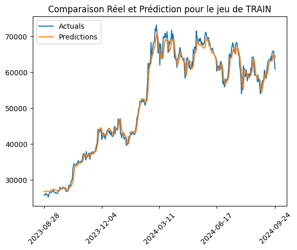

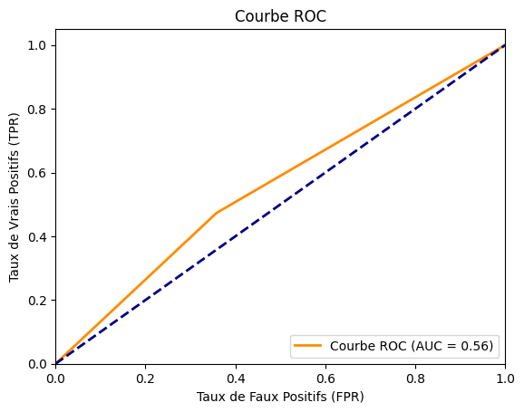

```
#####VAL#####
          Date    Actual N+7    Actual N+8  Predictions N+8  Actual UP or DOWN  Predicted UP or DOWN
0  2024-09-25  60825.742188  60649.281250     62660.847656                  0                     1
1  2024-09-26  60662.730469  60752.710938     61615.195312                  1                     1
2  2024-09-27  60770.464844  62086.000000     61200.851562                  1                     1
3  2024-09-28  62159.273438  62058.000000     61425.828125                  0                     0
4  2024-09-29  62130.113281  62819.910156     61769.914062                  1                     0
5  2024-09-30  62923.750000  62224.000000     62253.000000                  0                     0
6  2024-10-01  62303.027344  62160.488281     62398.902344                  0                     1
--Regression Metrics--
R^2 = 94.24551129341125%
MAE = 1688.994873046875
MSE = 5409172.0
RMSE = 2325.762670609364
MAPE = 2.3095114156603813%
MAX_ERROR = 8822.8984375
--Classification Metrics--
Accuracy = 53.06122448979592%
Precision = 50.0%
Recall = 43.47826086956522%
AUC = 0.5250836120401338
######MATRICE DE CONFUSION#######
              Predicted DOWN  Predicted UP
Actual DOWN              16            10
Actual UP                13            10
Le répertoire '/home/alexander.lunel/Private/ML/Projet_ml/figure/Model1_Close_price_jaquart_dense64_WS7-dataset_raw_1d_2023_08_28_2025_01_08-100' existe déjà.
```

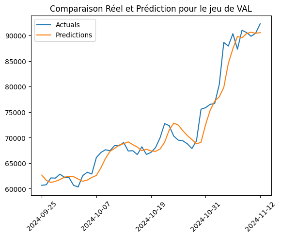

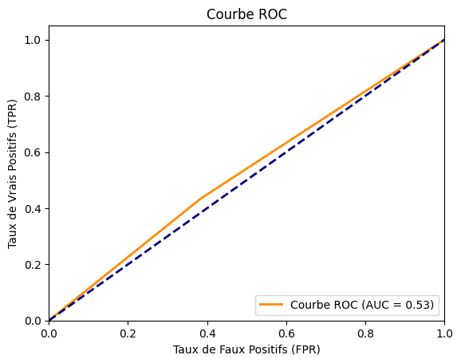

```
#####TEST#####
          Date     Actual N+7    Actual N+8  Predictions N+8  Actual UP or DOWN  Predicted UP or DOWN
0  2024-11-13   95720.609375  94286.562500     94837.109375                  0                     0
1  2024-11-14   97209.007812  98317.117188     96194.671875                  1                     0
2  2024-11-15  100245.312500  98892.000000     98438.046875                  0                     0
3  2024-11-16  100678.382812  97672.398438    100118.898438                  0                     0
4  2024-11-17   99759.625000  97900.039062    100512.218750                  0                     1
5  2024-11-18   99931.117188  93010.007812    100479.992188                  0                     1
6  2024-11-19   96247.351562  91965.156250     98648.476562                  0                     1
--Regression Metrics--
R^2 = -9.475195407867432%
MAE = 2561.893798828125
MSE = 10533163.0
RMSE = 3245.48347708011
MAPE = 2.658640407025814%
MAX_ERROR = 7469.984375
--Classification Metrics--
Accuracy = 54.0%
Precision = 24.0%
Recall = 60.0%
AUC = 0.5625
######MATRICE DE CONFUSION#######
              Predicted DOWN  Predicted UP
Actual DOWN              21            19
Actual UP                 4             6
Le répertoire '/home/alexander.lunel/Private/ML/Projet_ml/figure/Model1_Close_price_jaquart_dense64_WS7-dataset_raw_1d_2023_08_28_2025_01_08-100' existe déjà.
```

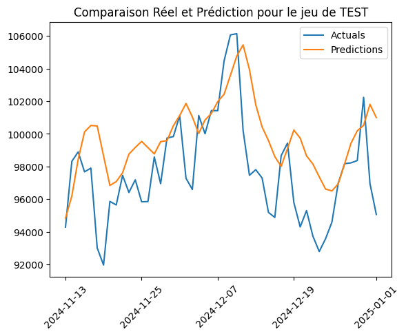

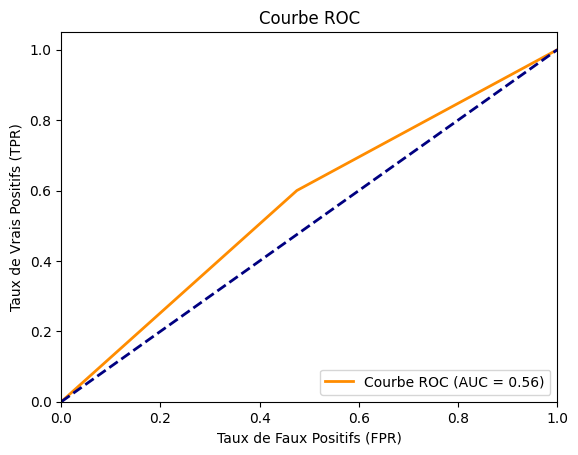

```python
main_analyze_model_close_price(full_model_name, WINDOW_SIZE)
```

Les résultats de ce premier modèle sont très intéressant et encourageant.

Pour ce qui est de la regression, le modèle obtient de bons résultats sur le jeu de test (malgré le bug du R^2 à cause du manque de données). L'erreur moyenne est de 2.65%, l'erreur max à 7469$, ce qui reste élevée dans une problématique de trading mais qui est prometteur pour un premier modèle.

Pour la classification, les résultats sont encore plus favorables. Nous obtenons une accuracy de 54%, ce qui correspond à un avantage élevé dans une place de marché. Tous les points d'accuracy sont très bons à prendre puisqu'ils donnent des avantages comparatifs importants et couplé un à bon risk management (trade en 2:1, risqué 1 pour gagner 2), une stratégie de trading sera rentable avec 54% de win rate.

Malgré tout le modèle n'est pas satisfasant, rien qu'au regard de la figure des prédictions par rapport au réel, on note facilement que ce modèle n'est pas stable et que ces résultats ne sont certainement pas significatifs. Nous pensons qu'entrainer le même modèle sur plus de données peut être une bonne idée afin de l'exposer à un plus grand nombre de patterns différents. C'est ce que nous faisons dans le modèle 2.

## Modèle 2: Close_price sur les données du 2017-08-17 au 2025-01-08

```python
WINDOW_SIZE = 7
N_EPOCHS = 100
data_name = "dataset_raw_1d_2017_08_17_2025_01_08"

datasets = main_pre_processing_close_price(data_name, WINDOW_SIZE)

model_name = f"Model2_Close_price_jaquart_dense64_WS{WINDOW_SIZE}"
full_model_name = model_name+'-'+data_name+'-'+str(N_EPOCHS)

X_train = datasets['TRAIN'][0][1]
y_train = datasets['TRAIN'][0][2]

X_val = datasets['VAL'][0][1]
y_val = datasets['VAL'][0][2]

main_training_model(full_model_name, X_train, y_train, X_val, y_val, WINDOW_SIZE, N_EPOCHS)
```

```
X.shape (2700, 7, 1)
y.shape (2700, 1)
X_train_norm.shape (2160, 7, 1)
y_train_norm.shape (2160, 1)
```

[output not shown]

[output not shown]

[output not shown]

[output not shown]

[output not shown]

[output not shown]

[output not shown]

[output not shown]

[output not shown]

[output not shown]

[output not shown]

[output not shown]

[output not shown]

[output not shown]

[output not shown]

[output not shown]

[output not shown]

[output not shown]

[output not shown]

[output not shown]

[output not shown]

[output not shown]

[output not shown]

[output not shown]

[output not shown]

[output not shown]

[output not shown]

[output not shown]

[output not shown]

[output not shown]

[output not shown]

[output not shown]

[output not shown]

[output not shown]

[output not shown]

[output not shown]

[output not shown]

[output not shown]

[output not shown]

[output not shown]

[output not shown]

[output not shown]

[output not shown]

[output not shown]

[output not shown]

[output not shown]

[output not shown]

[output not shown]

[output not shown]

[output not shown]

[output not shown]

[output not shown]

[output not shown]

[output not shown]

[output not shown]

[output not shown]

[output not shown]

[output not shown]

[output not shown]

[output not shown]

[output not shown]

[output not shown]

[output not shown]

[output not shown]

[output not shown]

[output not shown]

```
<keras.engine.sequential.Sequential at 0x7f8d3419cee0>
```

```
X.shape (2700, 7, 1)
y.shape (2700, 1)
X_train_norm.shape (2160, 7, 1)
y_train_norm.shape (2160, 1)
#####TRAIN#####
          Date   Actual N+7   Actual N+8  Predictions N+8  Actual UP or DOWN  Predicted UP or DOWN
0  2017-08-17  4114.009766  4316.009766      4419.860840                  1                     1
1  2017-08-18  4316.009766  4280.680176      4510.170898                  0                     1
2  2017-08-19  4280.680176  4337.439941      4566.543945                  1                     1
3  2017-08-20  4337.439941  4310.009766      4622.876465                  0                     1
4  2017-08-21  4310.009766  4386.689941      4648.521484                  1                     1
5  2017-08-22  4386.689941  4587.479980      4689.119629                  1                     1
6  2017-08-23  4587.479980  4555.140137      4790.011230                  0                     1
--Regression Metrics--
R^2 = 99.56466555595398%
MAE = 682.9632568359375
MSE = 1124935.875
RMSE = 1060.6299425341526
MAPE = 4.372286796569824%
MAX_ERROR = 6874.34375
--Classification Metrics--
Accuracy = 52.916666666666664%
Precision = 52.62557077625571%
Recall = 83.13796212804328%
AUC = 0.5208277744841745
######MATRICE DE CONFUSION#######
              Predicted DOWN  Predicted UP
Actual DOWN             221           830
Actual UP               187           922
Le répertoire '/home/alexander.lunel/Private/ML/Projet_ml/figure/Model2_Close_price_jaquart_dense64_WS7-dataset_raw_1d_2017_08_17_2025_01_08-100' existe déjà.
```

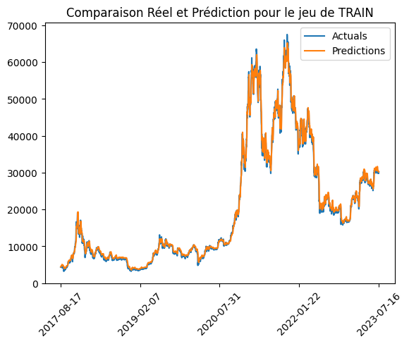

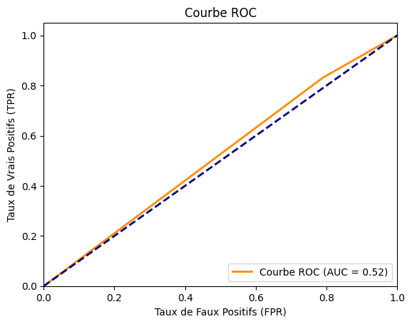

```
#####VAL#####
          Date    Actual N+7    Actual N+8  Predictions N+8  Actual UP or DOWN  Predicted UP or DOWN
0  2023-07-17  30083.750000  29176.500000     30081.271484                  0                     0
1  2023-07-18  29176.500000  29228.910156     29825.810547                  1                     1
2  2023-07-19  29228.910156  29351.960938     29653.980469                  1                     1
3  2023-07-20  29351.960938  29222.779297     29588.539062                  0                     1
4  2023-07-21  29222.779297  29314.140625     29513.285156                  1                     1
5  2023-07-22  29314.140625  29352.900391     29500.777344                  1                     1
6  2023-07-23  29352.900391  29281.089844     29514.564453                  0                     1
--Regression Metrics--
R^2 = 99.12652373313904%
MAE = 881.1315307617188
MSE = 1799996.875
RMSE = 1341.63962188063
MAPE = 1.9929513335227966%
MAX_ERROR = 5932.765625
--Classification Metrics--
Accuracy = 54.44444444444444%
Precision = 56.043956043956044%
Recall = 70.34482758620689%
AUC = 0.5317241379310345
######MATRICE DE CONFUSION#######
              Predicted DOWN  Predicted UP
Actual DOWN              45            80
Actual UP                43           102
Le répertoire '/home/alexander.lunel/Private/ML/Projet_ml/figure/Model2_Close_price_jaquart_dense64_WS7-dataset_raw_1d_2017_08_17_2025_01_08-100' existe déjà.
```

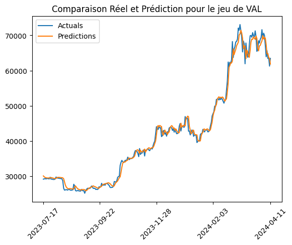

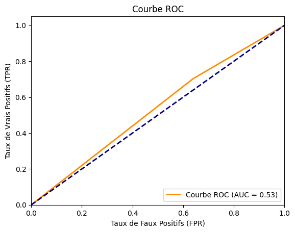

```
#####TEST#####
          Date    Actual N+7    Actual N+8  Predictions N+8  Actual UP or DOWN  Predicted UP or DOWN
0  2024-04-12  63470.082031  63818.007812     62871.902344                  1                     0
1  2024-04-13  63818.007812  64940.589844     63323.273438                  1                     0
2  2024-04-14  64940.589844  64941.148438     64262.925781                  1                     0
3  2024-04-15  64941.148438  66819.320312     64779.484375                  1                     0
4  2024-04-16  66819.320312  66414.000000     66171.156250                  0                     0
5  2024-04-17  66414.000000  64289.589844     66635.757812                  0                     1
6  2024-04-18  64289.589844  64498.339844     65516.582031                  1                     1
--Regression Metrics--
R^2 = 98.00628423690796%
MAE = 1564.5537109375
MSE = 4189035.25
RMSE = 2046.7132798709251
MAPE = 2.218705415725708%
MAX_ERROR = 8579.9453125
--Classification Metrics--
Accuracy = 49.25925925925926%
Precision = 50.0%
Recall = 54.74452554744526%
AUC = 0.49176774051918115
######MATRICE DE CONFUSION#######
              Predicted DOWN  Predicted UP
Actual DOWN              58            75
Actual UP                62            75
Le répertoire '/home/alexander.lunel/Private/ML/Projet_ml/figure/Model2_Close_price_jaquart_dense64_WS7-dataset_raw_1d_2017_08_17_2025_01_08-100' existe déjà.
```

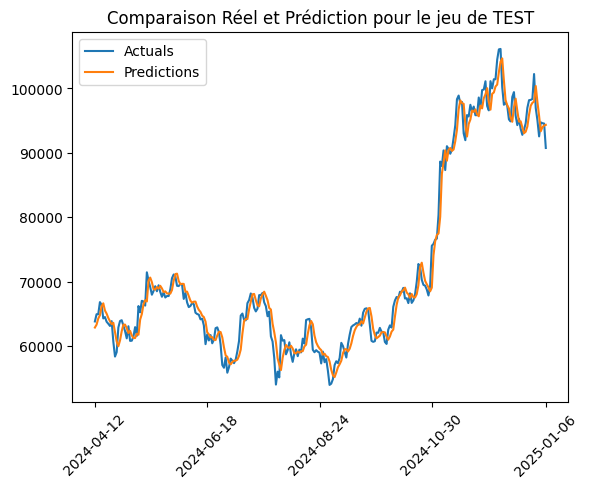

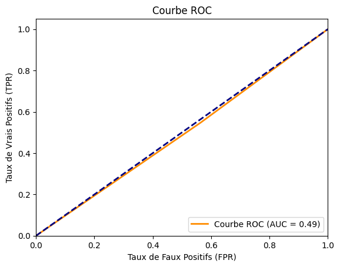

```python
main_analyze_model_close_price(full_model_name, WINDOW_SIZE)
```

Le fait d'ajouter beaucoup plus de données, a considérablement améliorer notre modèle sur sa capacité à interpoler la variable continue du prix. Toutes les erreurs, sauf l'erreur max, sont inférieures au modèle précédent sur le jeu de test. Nous remarquons d'ailleurs que les prédictions sont très proches du réel.

Pour ce qui est de la classification en revanche, le modèle a beaucoup perdu en performance. Une accuracy et une AUC inférieure à 50 points, la matrice de confusion confirme que le modèle n'arrive pas à distinguer les hausses des baisses.

## Modèle 3: Log_close_price sur les données du 2017-08-17 au 2025-01-08

Nous savons que le prix du bitcoin a beaucoup évoluer au cours de la dernière période d'entraînement de modèle, passant de 4000 à plus de 100 000$ et nous pensons que ceci nuit au performance de prédiction. Peut-être que le fait de mettre le prix en logarithmique permettra d'atténuer ces écarts de prédictions, qui empêchent de définir la direction du lendemain.

```python
WINDOW_SIZE = 7
N_EPOCHS = 100
data_name = "dataset_raw_1d_2017_08_17_2025_01_08"

datasets = main_pre_processing_log_close_price(data_name, WINDOW_SIZE)

model_name = f"Model3_Log_close_price_jaquart_dense64_WS{WINDOW_SIZE}"
full_model_name = model_name+'-'+data_name+'-'+str(N_EPOCHS)

X_train = datasets['TRAIN'][0][1]
y_train = datasets['TRAIN'][0][2]

X_val = datasets['VAL'][0][1]
y_val = datasets['VAL'][0][2]

main_training_model(full_model_name, X_train, y_train, X_val, y_val, WINDOW_SIZE, N_EPOCHS)
```

```
X.shape (2700, 7, 1)
y.shape (2700, 1)
X_train_norm.shape (2160, 7, 1)
y_train_norm.shape (2160, 1)
```

[output not shown]

[output not shown]

[output not shown]

[output not shown]

[output not shown]

[output not shown]

[output not shown]

[output not shown]

[output not shown]

[output not shown]

[output not shown]

[output not shown]

[output not shown]

[output not shown]

[output not shown]

[output not shown]

[output not shown]

[output not shown]

[output not shown]

[output not shown]

[output not shown]

[output not shown]

[output not shown]

[output not shown]

[output not shown]

[output not shown]

[output not shown]

[output not shown]

[output not shown]

[output not shown]

[output not shown]

[output not shown]

[output not shown]

[output not shown]

[output not shown]

[output not shown]

[output not shown]

[output not shown]

[output not shown]

[output not shown]

[output not shown]

[output not shown]

[output not shown]

[output not shown]

[output not shown]

[output not shown]

[output not shown]

[output not shown]

[output not shown]

[output not shown]

[output not shown]

[output not shown]

[output not shown]

[output not shown]

[output not shown]

[output not shown]

[output not shown]

[output not shown]

[output not shown]

[output not shown]

[output not shown]

[output not shown]

[output not shown]

[output not shown]

[output not shown]

[output not shown]

[output not shown]

[output not shown]

[output not shown]

[output not shown]

[output not shown]

[output not shown]

[output not shown]

[output not shown]

[output not shown]

[output not shown]

[output not shown]

[output not shown]

[output not shown]

[output not shown]

[output not shown]

[output not shown]

[output not shown]

[output not shown]

[output not shown]

[output not shown]

[output not shown]

[output not shown]

[output not shown]

[output not shown]

[output not shown]

[output not shown]

[output not shown]

[output not shown]

[output not shown]

[output not shown]

[output not shown]

[output not shown]

[output not shown]

[output not shown]

[output not shown]

[output not shown]

[output not shown]

[output not shown]

[output not shown]

[output not shown]

[output not shown]

[output not shown]

[output not shown]

[output not shown]

[output not shown]

[output not shown]

[output not shown]

[output not shown]

[output not shown]

[output not shown]

[output not shown]

[output not shown]

[output not shown]

[output not shown]

[output not shown]

[output not shown]

[output not shown]

[output not shown]

[output not shown]

[output not shown]

```
<keras.engine.sequential.Sequential at 0x7f8cac447af0>
```

```
X.shape (2700, 7, 1)
y.shape (2700, 1)
X_train_norm.shape (2160, 7, 1)
y_train_norm.shape (2160, 1)
#####TRAIN#####
          Date   Actual N+7   Actual N+8  Predictions N+8  Actual UP or DOWN  Predicted UP or DOWN
0  2017-08-17  4114.008301  4316.009766      3898.178711                  1                     0
1  2017-08-18  4316.009766  4280.679199      4018.665039                  0                     0
2  2017-08-19  4280.679199  4337.441895      4079.389404                  1                     0
3  2017-08-20  4337.441895  4310.008789      4139.854492                  0                     0
4  2017-08-21  4310.008789  4386.691406      4156.580078                  1                     0
5  2017-08-22  4386.691406  4587.481934      4194.117676                  1                     0
6  2017-08-23  4587.481934  4555.138672      4307.900879                  0                     0
--Regression Metrics--
R^2 = 99.52360987663269%
MAE = 701.7574462890625
MSE = 1231022.875
RMSE = 1109.51470247131
MAPE = 4.0105655789375305%
MAX_ERROR = 7279.21875
--Classification Metrics--
Accuracy = 50.324074074074076%
Precision = 52.59365994236311%
Recall = 32.91253381424707%
AUC = 0.5080450667876959
######MATRICE DE CONFUSION#######
              Predicted DOWN  Predicted UP
Actual DOWN             722           329
Actual UP               744           365
Répertoire '/home/alexander.lunel/Private/ML/Projet_ml/figure/Model3_Log_close_price_jaquart_dense64_WS7-dataset_raw_1d_2017_08_17_2025_01_08-100' créé avec succès.
```

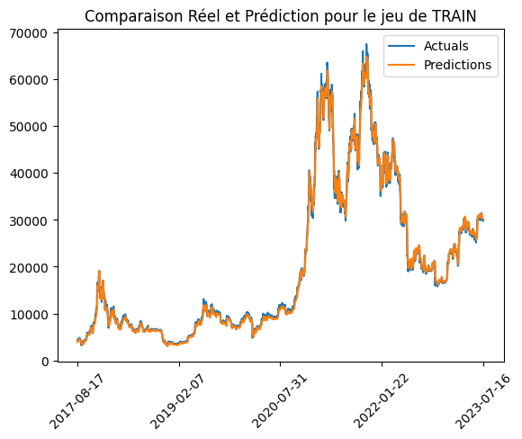

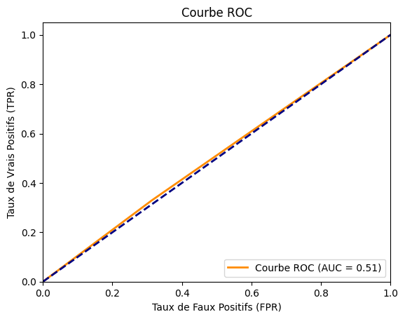

```
#####VAL#####
          Date    Actual N+7    Actual N+8  Predictions N+8  Actual UP or DOWN  Predicted UP or DOWN
0  2023-07-17  30083.763672  29176.484375     29644.314453                  0                     0
1  2023-07-18  29176.484375  29228.898438     29291.041016                  1                     1
2  2023-07-19  29228.898438  29351.947266     29078.761719                  1                     0
3  2023-07-20  29351.947266  29222.769531     29018.369141                  0                     0
4  2023-07-21  29222.769531  29314.152344     28939.246094                  1                     0
5  2023-07-22  29314.152344  29352.898438     28951.033203                  1                     0
6  2023-07-23  29352.898438  29281.099609     28989.462891                  0                     0
--Regression Metrics--
R^2 = 98.9808440208435%
MAE = 1001.1992797851562
MSE = 2100209.75
RMSE = 1449.2100434374584
MAPE = 2.320270799100399%
MAX_ERROR = 6879.31640625
--Classification Metrics--
Accuracy = 53.333333333333336%
Precision = 66.66666666666666%
Recall = 26.20689655172414%
AUC = 0.5550344827586208
######MATRICE DE CONFUSION#######
              Predicted DOWN  Predicted UP
Actual DOWN             106            19
Actual UP               107            38
Le répertoire '/home/alexander.lunel/Private/ML/Projet_ml/figure/Model3_Log_close_price_jaquart_dense64_WS7-dataset_raw_1d_2017_08_17_2025_01_08-100' existe déjà.
```

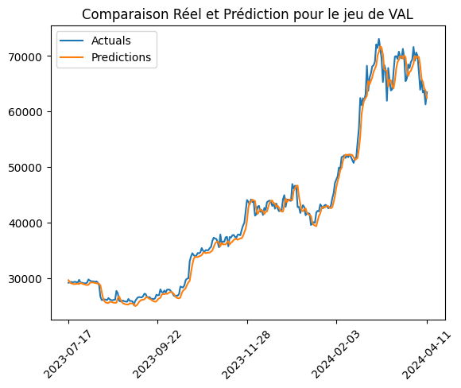

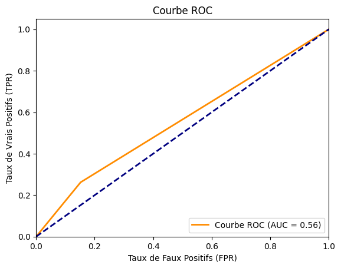

```
#####TEST#####
          Date    Actual N+7    Actual N+8  Predictions N+8  Actual UP or DOWN  Predicted UP or DOWN
0  2024-04-12  63470.078125  63817.984375     62465.632812                  1                     0
1  2024-04-13  63817.984375  64940.531250     62886.667969                  1                     0
2  2024-04-14  64940.531250  64941.152344     63671.781250                  1                     0
3  2024-04-15  64941.152344  66819.343750     64212.609375                  1                     0
4  2024-04-16  66819.343750  66414.015625     65306.531250                  0                     0
5  2024-04-17  66414.015625  64289.574219     65782.968750                  0                     0
6  2024-04-18  64289.574219  64498.371094     64996.792969                  1                     1
--Regression Metrics--
R^2 = 97.73433208465576%
MAE = 1654.44140625
MSE = 4760436.0
RMSE = 2181.8423407753367
MAPE = 2.3197945207357407%
MAX_ERROR = 9408.3671875
--Classification Metrics--
Accuracy = 51.11111111111111%
Precision = 52.94117647058824%
Recall = 32.846715328467155%
AUC = 0.5138576367927117
######MATRICE DE CONFUSION#######
              Predicted DOWN  Predicted UP
Actual DOWN              93            40
Actual UP                92            45
Le répertoire '/home/alexander.lunel/Private/ML/Projet_ml/figure/Model3_Log_close_price_jaquart_dense64_WS7-dataset_raw_1d_2017_08_17_2025_01_08-100' existe déjà.
```

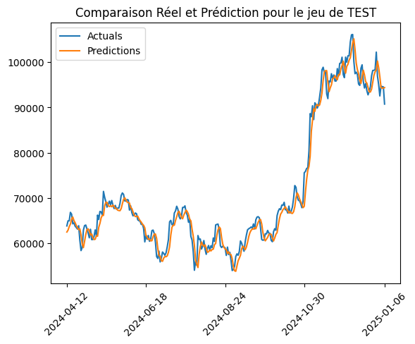

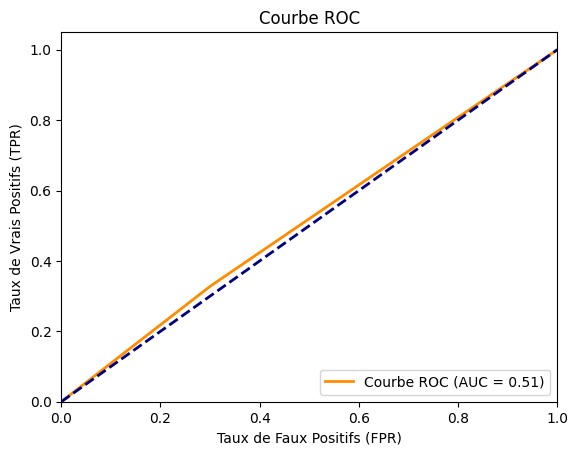

```python
main_analyze_model_log_close_price(full_model_name, WINDOW_SIZE)
```

Le constat est simple, le modèle n'est pas meilleur que le précédent, tant sur la régression que sur la classification.

Les erreurs sont toutes plus importantes que les précédentes sur le jeu de test. Les accuracy et AUC n'ont pas significativement évolués et on note que la matrice de confusion est largement déséquilibré vers la prédiction à la baisse alors que la période d'entrainement est une période plus haussière que baissière.

On remarque en fait, sur le graphique des prédictions, que celles-ci "suivent" le cours réel comme si elles lissaient l'évolution du prix.

Pour comprendre le phénomène, on peut observer les predictions et le réel à la dernière date du jeu de test. On remarque qu'alors que le prix réel baisse drastiquement, la prédiction semble se retourner à la hausse, indiquant que le mouvement n'a pas du tout était prévu. Et cela semble être la réelle faille: à un jour $n$, il semble que la capacité de prédiction de hausse ou de baisse à $n_{+1}$ soit équivalente à celle d'un lancer de pièce.

Comme l'IA l'avait expliquer, le modèle semble incapable de prédire des évènements erratiques (des évènements qu'il n'aura pas déjà vu), choses communes dans le marché. Nous pouvons imaginer que le modèle peut s'améliorer en lui ajoutant plus de données. Potentiellement plus de jours ou, comme nous avons choisi de le faire, en créant des nouvelles variables qui viendront expliquer le mouvement du prix.

Nous avons ajouté quelques variables comme le jour, le mois, l'évolution en pourcentage. Nous avons aussi implémenter des indicateurs d'analyse technique. Ils ont été présenté précedemment, et nous espérons qu'ils permettrons une meilleure prédiction.

## Modèle 4: dataset_v2 avec log_close_price sur les données du 2017-08-17 au 2025-01-08

```python
"""
preprocess2 les données data_name et entraine un modele model_name
"""
WINDOW_SIZE = 7
N_EPOCHS = 100
data_name = "dataset_v2_1d_2017_08_17_2025_01_08"

datasets = main_pre_processing_multivar(data_name, WINDOW_SIZE)

model_name = f"Model4_multi_var_jaquart_dense64_WS{WINDOW_SIZE}"
full_model_name = model_name+'-'+data_name+'-'+str(N_EPOCHS)

X_train = datasets['TRAIN'][0][1]
y_train = datasets['TRAIN'][0][2]

X_val = datasets['VAL'][0][1]
y_val = datasets['VAL'][0][2]

main_training_model(full_model_name, X_train, y_train, X_val, y_val, WINDOW_SIZE, N_EPOCHS)
```

```
Index(['log_close_price', 'Open_price', 'High_price', 'Low_price', 'Volume',
       'Quote_volume', 'Nb_trades', 'Taker_buy_base_volume',
       'Taker_buy_quote_volume', 'evolution_prct', 'lundi', 'mardi',
       'mercredi', 'jeudi', 'vendredi', 'samedi', 'dimanche', 'janvier',
       'fevrier', 'mars', 'avril', 'mai', 'juin', 'juillet', 'aout',
       'septembre', 'octobre', 'novembre', 'decembre', 'RSI', 'EMA_14', 'MACD',
       'MACD_Signal'],
      dtype='object')
X.shape (2667, 7, 33)
y.shape (2667,)
X_train_norm.shape (2133, 7, 33)
y_train_norm.shape (2133, 1)
```

[output not shown]

[output not shown]

[output not shown]

[output not shown]

[output not shown]

[output not shown]

[output not shown]

[output not shown]

[output not shown]

[output not shown]

[output not shown]

[output not shown]

[output not shown]

[output not shown]

[output not shown]

[output not shown]

[output not shown]

[output not shown]

[output not shown]

[output not shown]

[output not shown]

[output not shown]

[output not shown]

[output not shown]

[output not shown]

[output not shown]

[output not shown]

[output not shown]

[output not shown]

[output not shown]

[output not shown]

[output not shown]

[output not shown]

[output not shown]

[output not shown]

[output not shown]

[output not shown]

[output not shown]

[output not shown]

[output not shown]

[output not shown]

[output not shown]

[output not shown]

[output not shown]

[output not shown]

[output not shown]

[output not shown]

[output not shown]

[output not shown]

[output not shown]

[output not shown]

[output not shown]

[output not shown]

[output not shown]

[output not shown]

[output not shown]

[output not shown]

[output not shown]

[output not shown]

[output not shown]

[output not shown]

[output not shown]

[output not shown]

[output not shown]

[output not shown]

[output not shown]

[output not shown]

[output not shown]

[output not shown]

[output not shown]

[output not shown]

[output not shown]

[output not shown]

[output not shown]

[output not shown]

[output not shown]

[output not shown]

[output not shown]

[output not shown]

[output not shown]

[output not shown]

[output not shown]

[output not shown]

[output not shown]

[output not shown]

[output not shown]

[output not shown]

[output not shown]

[output not shown]

[output not shown]

[output not shown]

[output not shown]

[output not shown]

[output not shown]

[output not shown]

[output not shown]

[output not shown]

[output not shown]

[output not shown]

[output not shown]

[output not shown]

[output not shown]

[output not shown]

[output not shown]

[output not shown]

[output not shown]

[output not shown]

[output not shown]

[output not shown]

[output not shown]

[output not shown]

[output not shown]

[output not shown]

[output not shown]

[output not shown]

[output not shown]

[output not shown]

[output not shown]

[output not shown]

[output not shown]

[output not shown]

[output not shown]

[output not shown]

[output not shown]

[output not shown]

[output not shown]

[output not shown]

[output not shown]

[output not shown]

[output not shown]

[output not shown]

[output not shown]

[output not shown]

[output not shown]

[output not shown]

```
<keras.engine.sequential.Sequential at 0x7f8cac2c71c0>
```

```
Index(['log_close_price', 'Open_price', 'High_price', 'Low_price', 'Volume',
       'Quote_volume', 'Nb_trades', 'Taker_buy_base_volume',
       'Taker_buy_quote_volume', 'evolution_prct', 'lundi', 'mardi',
       'mercredi', 'jeudi', 'vendredi', 'samedi', 'dimanche', 'janvier',
       'fevrier', 'mars', 'avril', 'mai', 'juin', 'juillet', 'aout',
       'septembre', 'octobre', 'novembre', 'decembre', 'RSI', 'EMA_14', 'MACD',
       'MACD_Signal'],
      dtype='object')
X.shape (2667, 7, 33)
y.shape (2667,)
X_train_norm.shape (2133, 7, 33)
y_train_norm.shape (2133, 1)
#####TRAIN#####
          Date   Actual N+7   Actual N+8  Predictions N+8  Actual UP or DOWN  Predicted UP or DOWN
0  2017-09-19  3920.750244  3882.351807      4074.486084                  0                     1
1  2017-09-20  3882.351807  4193.001953      4080.405029                  1                     1
2  2017-09-21  4193.001953  4174.500977      4296.179688                  0                     1
3  2017-09-22  4174.500977  4174.691895      4425.450195                  1                     1
4  2017-09-23  4174.691895  4378.508301      4340.868652                  1                     1
5  2017-09-24  4378.508301  4378.478516      4504.465820                  0                     1
6  2017-09-25  4378.478516  4379.999023      4487.995605                  1                     1
--Regression Metrics--
R^2 = 98.1255292892456%
MAE = 1252.7969970703125
MSE = 4834265.0
RMSE = 2198.6962045721552
MAPE = 4.820767417550087%
MAX_ERROR = 12581.0
--Classification Metrics--
Accuracy = 52.18002812939522%
Precision = 56.91202872531418%
Recall = 28.89699179580675%
AUC = 0.528654843148918
######MATRICE DE CONFUSION#######
              Predicted DOWN  Predicted UP
Actual DOWN             796           240
Actual UP               780           317
Répertoire '/home/alexander.lunel/Private/ML/Projet_ml/figure/Model4_multi_var_jaquart_dense64_WS7-dataset_v2_1d_2017_08_17_2025_01_08-100' créé avec succès.
```

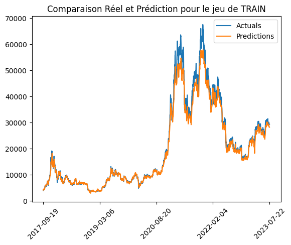

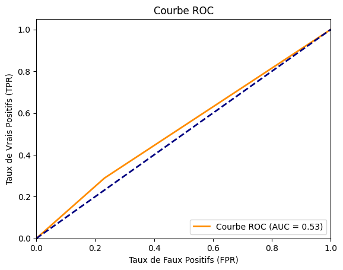

```
#####VAL#####
          Date    Actual N+7    Actual N+8  Predictions N+8  Actual UP or DOWN  Predicted UP or DOWN
0  2023-07-23  29352.898438  29281.099609     31206.363281                  0                     1
1  2023-07-24  29281.099609  29232.244141     31460.595703                  0                     1
2  2023-07-25  29232.244141  29705.980469     31487.310547                  1                     1
3  2023-07-26  29705.980469  29186.001953     32032.732422                  0                     1
4  2023-07-27  29186.001953  29193.628906     31594.423828                  1                     1
5  2023-07-28  29193.628906  29114.003906     31509.689453                  0                     1
6  2023-07-29  29114.003906  29072.134766     30926.152344                  0                     1
--Regression Metrics--
R^2 = 90.8465564250946%
MAE = 3615.254638671875
MSE = 19251698.0
RMSE = 4387.675694487914
MAPE = 8.381430804729462%
MAX_ERROR = 9483.0546875
--Classification Metrics--
Accuracy = 53.93258426966292%
Precision = 55.1219512195122%
Recall = 78.47222222222221%
AUC = 0.5183773712737128
######MATRICE DE CONFUSION#######
              Predicted DOWN  Predicted UP
Actual DOWN              31            92
Actual UP                31           113
Le répertoire '/home/alexander.lunel/Private/ML/Projet_ml/figure/Model4_multi_var_jaquart_dense64_WS7-dataset_v2_1d_2017_08_17_2025_01_08-100' existe déjà.
```

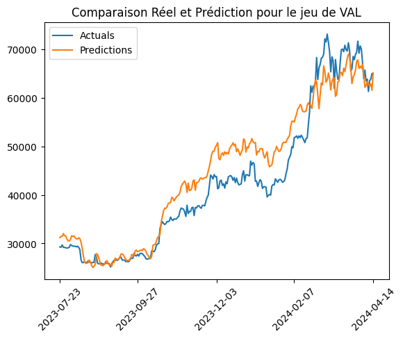

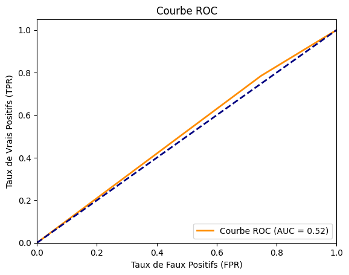

```
#####TEST#####
          Date    Actual N+7    Actual N+8  Predictions N+8  Actual UP or DOWN  Predicted UP or DOWN
0  2024-04-15  64941.152344  66819.343750     71250.687500                  1                     1
1  2024-04-16  66819.343750  66414.015625     74049.570312                  0                     1
2  2024-04-17  66414.015625  64289.574219     74189.109375                  0                     1
3  2024-04-18  64289.574219  64498.371094     72147.101562                  1                     1
4  2024-04-19  64498.371094  63769.984375     71680.062500                  0                     1
5  2024-04-20  63769.984375  63461.964844     70230.992188                  0                     1
6  2024-04-21  63461.964844  63118.648438     69496.695312                  0                     1
--Regression Metrics--
R^2 = 85.56135296821594%
MAE = 4822.32373046875
MSE = 30598374.0
RMSE = 5531.579702038108
MAPE = 7.2020575404167175%
MAX_ERROR = 11513.796875
--Classification Metrics--
Accuracy = 50.936329588014985%
Precision = 50.617283950617285%
Recall = 91.7910447761194%
AUC = 0.5078274043317248
######MATRICE DE CONFUSION#######
              Predicted DOWN  Predicted UP
Actual DOWN              13           120
Actual UP                11           123
Le répertoire '/home/alexander.lunel/Private/ML/Projet_ml/figure/Model4_multi_var_jaquart_dense64_WS7-dataset_v2_1d_2017_08_17_2025_01_08-100' existe déjà.
```

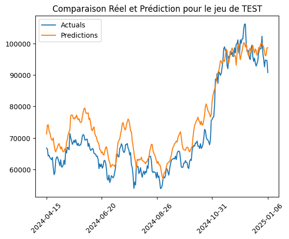

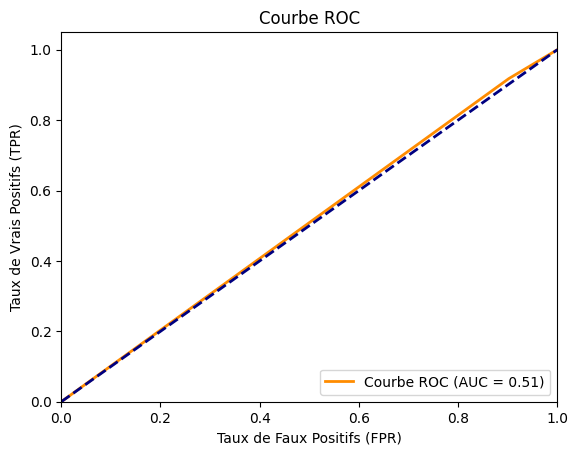

```python
main_analyze_model_multivar(full_model_name, WINDOW_SIZE)
```

Les résultats de ce dernier modèle sont très surprenants. On observe déjà un décrochage sur le jeu d'entraînement, qui se répercute sur la validation et le test. Simplement en étudiant, ces évolutions graphiques, on sent que le modèle à appris des patterns. Ces mouvements sont souvent plus explosifs sur les validations et tests, il est même parfois en avance sur le réel.

En matière, le modèle contenant toutes les variables est absolument inutilisable. Pourtant, il semble avoir réellement appris des patterns d'évolution du prix. Certainement trop appris sur le peu de données qu'on lui a fourni. Il ne parait pas déraisonnable de dire que le modèle peut être performant avec BEAUCOUP plus de données (cours des stocks boursiers sur des décennies, d'autre cryptos assez capitalisées, utilisation de plus d'indicateurs etc...).

# **`4.Communication des résultats`**

## Analyse vulgarisée des résultats

- Produisez une analyse claire des résultats pour un public non technique.

Analyse :

Comme on peut le voir sur les graphiques de comparaison entre les valeurs prédites et les valeurs réelles, que ce soit sur les valeurs d'entrainement, de validation et de test, le modèle arrive à reproduire très fidèlement le mouvement du cours du bitcoin. Ses prédictions sont assez juste et collent parfaitement au mouvement du marché.

Mais notre modèle subit un retard. C'est-à-dire que la prédiction réalisée n'arrive jamais assez proche du vrai prix à $n_{+1}$ pour coller avec la vraie évolution du cours. Il s'adaptera donc au jour suivant $n_{+2}$ et rattrapera son retard. Nous avons donc un modèle reproduisant bien le mouvement mais qui n'est pas réellement fait pour de la prédiction même à un horizon court.

# **`5.Retour d'expérience`**

## Utilité de l'IA

- L’IA vous a-t-elle été utile ?

Réponse :

Oui l'IA nous a en effet été utile sur plusieurs points :

- Nous avons pu avoir un **retour critique** sur notre travail ainsi qu'une vision externe et objectif sur ce qui allait et ce qui n'allait pas.
- Elle a pu nous aider à **soulever de nouveaux points de réfléxion** de nous n'avions pas penser.
- Elle a pu nous aider à **débuger** et à **construire du code** de manière beaucoup plus rapide que si l'on faisait tout nous même.
- Dans la compréhension du modèle LSTM, en plus des multiples vidéo Youtube regardés *(par exemple, ce Youtuber : www.youtube.com/@GregHogg)* et de la documentation Tensorflow, l'IA a pu nous aidé à comprendre le fonctionnement du modèle LSTM, de son implémentation en ligne de code python et de l'utilisation de Tensorflow en général.

## Défis rencontrés

- Quels défis avez-vous rencontrés ?

Réponse :

Après l'échec de la modélisation via les modèles classiques proposés sur scikit-learn, nous avons du utilisé un nouveau module, **Tensorflow**. La première difficulté avec Tensorflow est son installation. Pour Alexander, étant sur Mac, l'installation était un calvaire et il n'a pas pu l'installer, il s'est donc reporter sur Margaux (machine virtuelle de la fac) pour pouvoir l'utiliser. Pour Najim, étant sur Windows, il a juste eu besoin de changer de version de python, basculer de la 3.13 à la **version 3.11** pour pouvoir l'utiliser.  
Nous avons donc du apprendre l'utilisation d'un nouveau module de machine learning/deep learning pour pouvoir mener notre projet à bien et ce n'était pas une mince affaire...  
Nous avons également eu beaucoup de difficulté à comprendre comment fonctionne la construction d'un réseau de neurone LSTM sur Tensorflow même si cela reste plus facile que **PyTorch**, que nous avons également testé, mais la construction est plus complexe même si plus flexible à un certain niveau, mais nous avons voulu rester simple et opter pour Tensorflow.

Réalisation en fin de projet que le modèle utilisé n'est pas vraiment le bon modèle à utiliser si l'on veut prédire à N+1 la tendance du cours du Bitcoin.

## Comment améliorer l'intégration de l'IA dans ce type de projet

- Comment améliorer son intégration dans ce type de projet ?

Réponse :

Pour améliorer l'utilisation de l'IA dans ce type de projet on peut émettre quelque recommendations :

- Utiliser l'IA pour faire tout le code sans n'y rien comprendre n'est pas coneillé car l'utilisateur n'apprendra rien de ce qu'il fait.
- Utiliser l'IA activement pour **débuguer du code** par contre est très utile et même nécessaire pour éviter de grosse erreurs.
- Utiliser l'IA pour **optimiser le code**, certaines fois, 20 lignes de codes sont écrites alors que 5 suffisent...

## Considération éthiques

- Voyez-vous des considérations éthiques ?

Réponse :

L'IA peut être très utile et d'une aide précieuse pour le développement de ce type de projet, surtout au niveau du code comme expliqué précédemment. L'IA pour définir les objectifs d'un projet ou la problématique pose un peu plus de problèmes à notre goût car elle pourrait ne pas nous guider vers ce que l'on veut réellement, même si dans la réalité, en entreprise, on fixe d'abord le besoin et la problématique, avec la solution à apporter avant de se lancer dans ce type de projet.

Une vidéo intéressante sur le sujet de l'éthique de l'IA est la vidéo Youtube de EGO "L'horreur existentielle de l'usine à trombones."  
Lien : https://youtu.be/ZP7T6WAK3Ow?feature=shared